# miPEP_H_ITS_script

```r
#Statistical analyses: be careful, if updating code: this part has to be manually (export/import)

alpha.diversity_soil=estimate_richness(phylo_rar_soil, measures=c("Observed","Shannon", "Simpson"))
#write.table(alpha.diversity_soil, ("indice_diversite_soil.txt"))

#Add a "Type" column and re-import as Text(readr)

library(readr)
indice_diversite_soil <-read_delim("C:/Users/hmiddleton/Dropbox/Projet_Mutants_miPEPs_miRNA/Harriet/Metabarcoding_mutants_and_miPEP/Analyses_métabarcoding/miPEP_H/ITS/indice_diversite_soil_1.txt","\t", escape_double = FALSE, trim_ws = TRUE)
indice_diversite_soil$Type <- as.factor(indice_diversite_soil$Type)
str(object = indice_diversite_soil$Type)
```

```
##  Factor w/ 4 levels "Control-mi-PEP",..: 2 2 2 2 2 2 2 3 3 3 ...
```

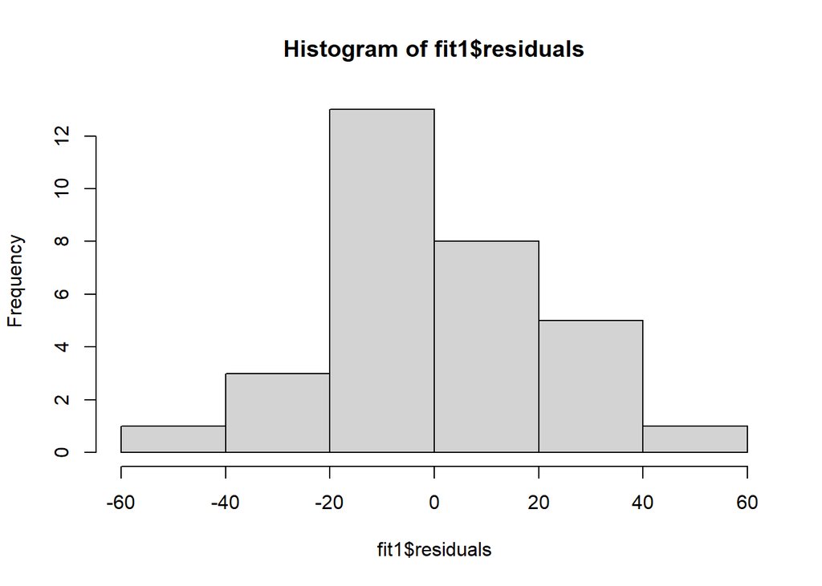

```r
indice_diversite_soil$Type <- relevel(indice_diversite_soil$Type, ref="Control-mi-PEP")

fit1 <-lm(Observed~Type, data=indice_diversite_soil)
hist(fit1$residuals) #suit une loi normale?
```

```r
shapiro.test(fit1$residuals)# si p-value > 0,05 alors la distribution n'est pas significativement différente d'une distribution normale
```

```
##
##  Shapiro-Wilk normality test
##
## data:  fit1$residuals
## W = 0.98576, p-value = 0.9443
```

```r
summary(fit1)
```

```
##
## Call:
## lm(formula = Observed ~ Type, data = indice_diversite_soil)
##
## Residuals:
##     Min      1Q  Median      3Q     Max
## -45.875 -13.670  -0.875  12.250  41.125
##
## Coefficients:
##             Estimate Std. Error t value Pr(>|t|)
## (Intercept)   47.875      7.170   6.677 3.63e-07 ***
## TypemiPEP-A    3.839     10.496   0.366    0.717
## TypemiPEP-B   -9.000     10.140  -0.888    0.383
## TypemiPEP-C    4.750     10.140   0.468    0.643
## ---
## Signif. codes:  0 '***' 0.001 '**' 0.01 '*' 0.05 '.' 0.1 ' ' 1
##
## Residual standard error: 20.28 on 27 degrees of freedom
## Multiple R-squared:  0.07728,    Adjusted R-squared:  -0.02525
## F-statistic: 0.7537 on 3 and 27 DF,  p-value: 0.5298
```

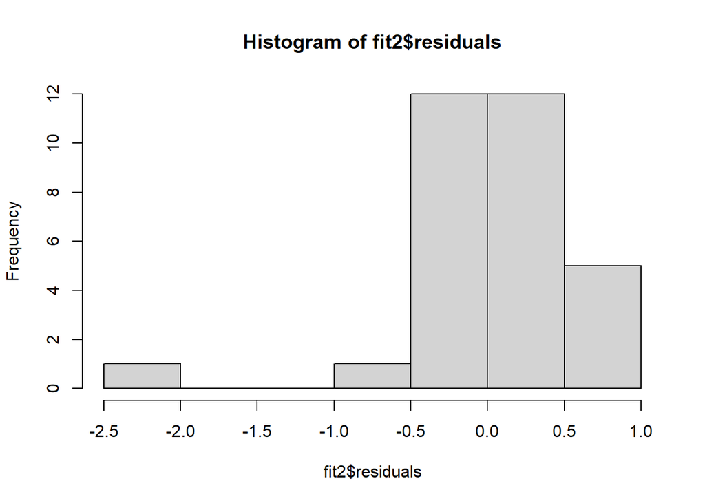

```r
fit2 <-lm(Shannon~Type, data=indice_diversite_soil)
hist(fit2$residuals) #suit une loi normale?
```

```r
shapiro.test(fit2$residuals)
```

```
##
##  Shapiro-Wilk normality test
##
## data:  fit2$residuals
## W = 0.82311, p-value = 0.0001425
```

```r
glm_fit2 <- glm(Shannon~Type, data=indice_diversite_soil) #link="inverse" by default
summary(glm_fit2)
```

```
##
## Call:
## glm(formula = Shannon ~ Type, data = indice_diversite_soil)
##
## Deviance Residuals:
##      Min        1Q    Median        3Q       Max
## -2.32016  -0.17931   0.04888   0.30202   0.78000
##
## Coefficients:
##             Estimate Std. Error t value Pr(>|t|)
## (Intercept)  2.70245    0.21764  12.417 1.13e-12 ***
## TypemiPEP-A  0.30554    0.31860   0.959    0.346
## TypemiPEP-B  0.07001    0.30779   0.227    0.822
## TypemiPEP-C  0.38324    0.30779   1.245    0.224
## ---
## Signif. codes:  0 '***' 0.001 '**' 0.01 '*' 0.05 '.' 0.1 ' ' 1
##
## (Dispersion parameter for gaussian family taken to be 0.3789477)
##
##     Null deviance: 11.027  on 30  degrees of freedom
## Residual deviance: 10.232  on 27  degrees of freedom
## AIC: 63.61
##
## Number of Fisher Scoring iterations: 2
```

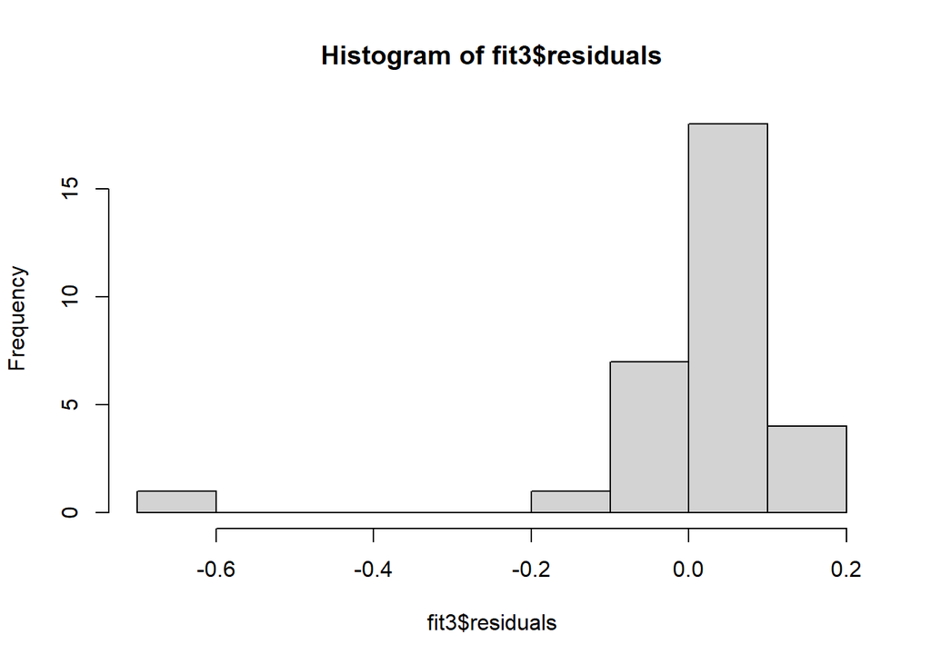

```r
fit3 <-lm(Simpson~Type, data=indice_diversite_soil)
hist(fit3$residuals) #suit une loi normale? if not normal try a GLM
```

```r
shapiro.test(fit3$residuals)
```

```
##
##  Shapiro-Wilk normality test
##
## data:  fit3$residuals
## W = 0.59222, p-value = 4.186e-08
```

```r
glm_fit3 <- glm(Simpson~Type, data=indice_diversite_soil) #link="inverse" by default
summary(glm_fit3)
```

```
##
## Call:
## glm(formula = Simpson ~ Type, data = indice_diversite_soil)
##
## Deviance Residuals:
##      Min        1Q    Median        3Q       Max
## -0.60041  -0.00963   0.00971   0.04444   0.13364
##
## Coefficients:
##             Estimate Std. Error t value Pr(>|t|)
## (Intercept)  0.82343    0.04644  17.730   <2e-16 ***
## TypemiPEP-A  0.08571    0.06798   1.261    0.218
## TypemiPEP-B  0.07098    0.06568   1.081    0.289
## TypemiPEP-C  0.09939    0.06568   1.513    0.142
## ---
## Signif. codes:  0 '***' 0.001 '**' 0.01 '*' 0.05 '.' 0.1 ' ' 1
##
## (Dispersion parameter for gaussian family taken to be 0.0172552)
##
##     Null deviance: 0.51236  on 30  degrees of freedom
## Residual deviance: 0.46589  on 27  degrees of freedom
## AIC: -32.157
##
## Number of Fisher Scoring iterations: 2
```

Alpha-diversity in unplanted soils…

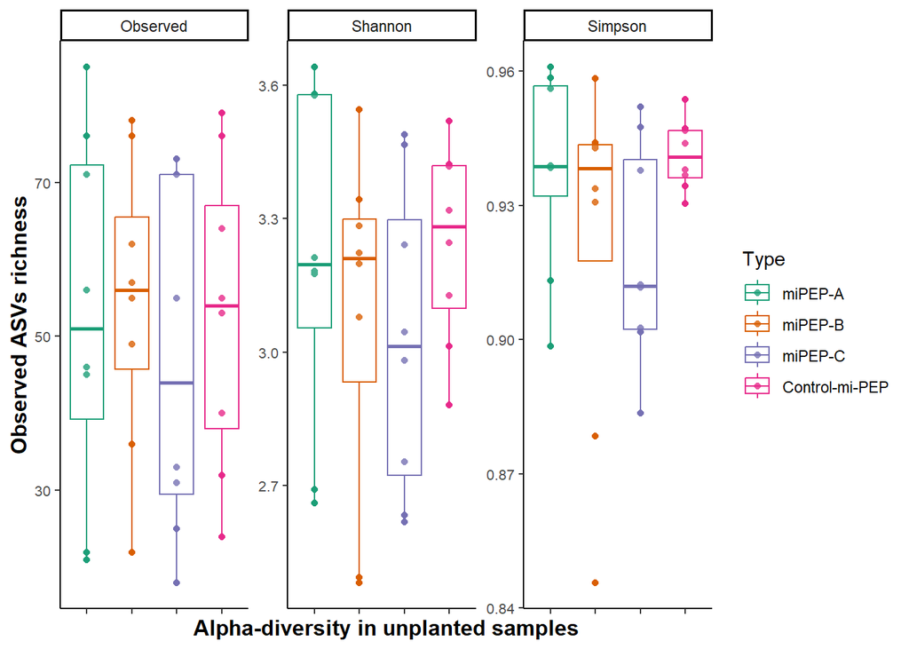

```r
p_Div_unplanted=plot_richness(phylo_rar_unplanted, color="Type", x="Type", measures=c("Observed", "Shannon", "Simpson"))
p_Div_unplanted_bp=p_Div_unplanted+geom_boxplot(aes(color=Type), alpha=0.2)+ theme_classic()+xlab("Alpha-diversity in unplanted samples")+ylab("Observed ASVs richness")+ theme(axis.text.y = element_text (), axis.text.x = element_blank (), axis.text =element_text(size=8), axis.title=element_text(size=12,face="bold"))+scale_color_manual(values=c("#1B9E77", "#D95F02", "#7570B3", "#E7298A", "#66A61E", "#E6AB02", "#A6761D","#666666"))

p_Div_unplanted_bp
```

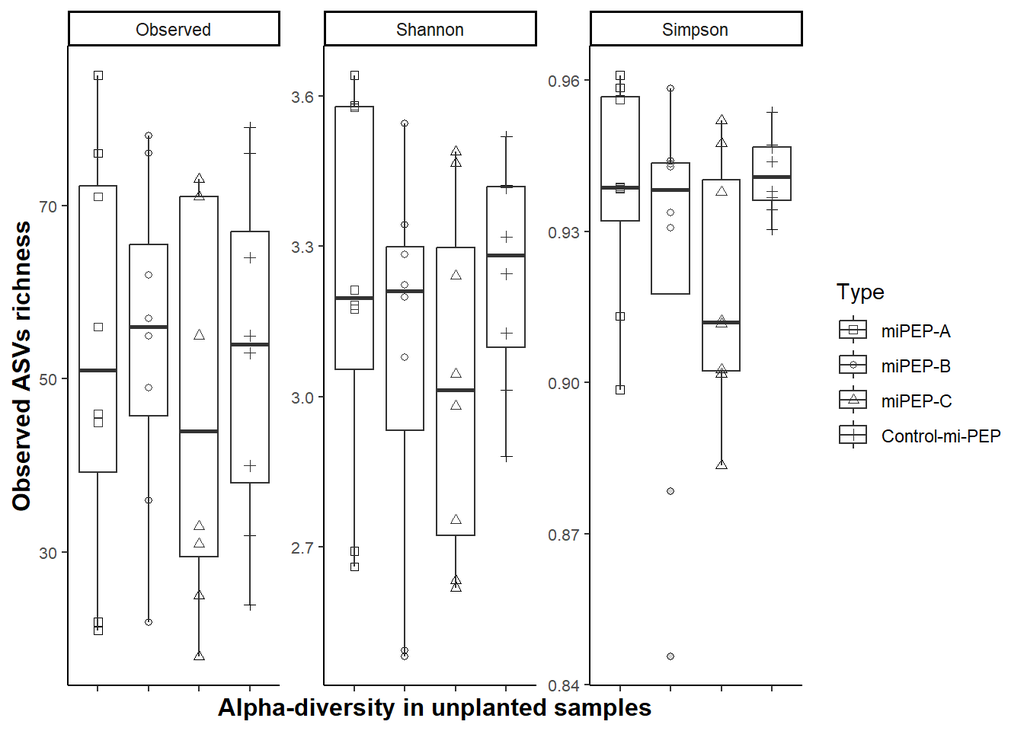

```r
# en noir et blanc avec des formes
p_Div_unplanted=plot_richness(phylo_rar_unplanted, shape="Type", x="Type", measures=c("Observed", "Shannon", "Simpson"))
p_Div_unplanted_bp_nb <- p_Div_unplanted+geom_boxplot(aes(shape=Type), alpha=0.2) + scale_shape_manual(values=c(0,1,2,3,19,15,8))+ theme_classic()+xlab("Alpha-diversity in unplanted samples")+ylab("Observed ASVs richness")+ theme(axis.text.y = element_text (), axis.text.x = element_blank (), axis.text =element_text(size=8), axis.title=element_text(size=12,face="bold"))
p_Div_unplanted_bp_nb
```

```r
#Statistical analyses: be careful, if updating code: this part has to be manually (export/import)

alpha.diversity_unplanted=estimate_richness(phylo_rar_unplanted, measures=c("Observed","Shannon", "Simpson"))
#write.table(alpha.diversity_unplanted, ("indice_diversite_unplanted.txt"))

#Add a "Type" column and re-import as Text(readr)

library(readr)
indice_diversite_unplanted <-read_delim("C:/Users/hmiddleton/Dropbox/Projet_Mutants_miPEPs_miRNA/Harriet/Metabarcoding_mutants_and_miPEP/Analyses_métabarcoding/miPEP_H/ITS/indice_diversite_unplanted_1.txt","\t", escape_double = FALSE, trim_ws = TRUE)
indice_diversite_unplanted$Type <- as.factor(indice_diversite_unplanted$Type)
str(object = indice_diversite_unplanted$Type)
```

```
##  Factor w/ 4 levels "Control-mi-PEP",..: 2 2 2 2 2 2 2 2 3 3 ...
```

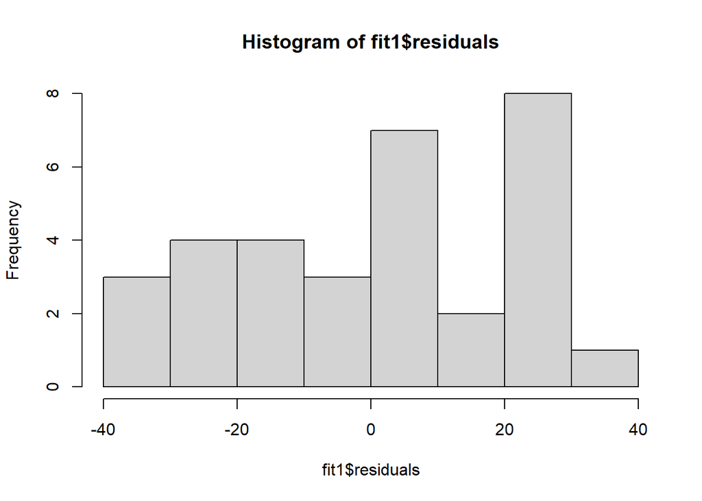

```r
indice_diversite_unplanted$Type <- relevel(indice_diversite_unplanted$Type, ref="Control-mi-PEP")

fit1 <-lm(Observed~Type, data=indice_diversite_unplanted)
hist(fit1$residuals) #suit une loi normale?
```

```r
shapiro.test(fit1$residuals)# si p-value > 0,05 alors la distribution n'est pas significativement différente d'une distribution normale
```

```
##
##  Shapiro-Wilk normality test
##
## data:  fit1$residuals
## W = 0.92927, p-value = 0.03737
```

```r
glm_fit1 <- glm(Observed~Type, data=indice_diversite_unplanted) #link="inverse" by default
summary(glm_fit1)
```

```
##
## Call:
## glm(formula = Observed ~ Type, data = indice_diversite_unplanted)
##
## Deviance Residuals:
##     Min       1Q   Median       3Q      Max
## -32.375  -16.687    1.375   22.000   32.250
##
## Coefficients:
##             Estimate Std. Error t value Pr(>|t|)
## (Intercept)   52.875      7.600   6.957 1.45e-07 ***
## TypemiPEP-A   -0.125     10.748  -0.012    0.991
## TypemiPEP-B    1.500     10.748   0.140    0.890
## TypemiPEP-C   -5.750     10.748  -0.535    0.597
## ---
## Signif. codes:  0 '***' 0.001 '**' 0.01 '*' 0.05 '.' 0.1 ' ' 1
##
## (Dispersion parameter for gaussian family taken to be 462.1116)
##
##     Null deviance: 13183  on 31  degrees of freedom
## Residual deviance: 12939  on 28  degrees of freedom
## AIC: 292.88
##
## Number of Fisher Scoring iterations: 2
```

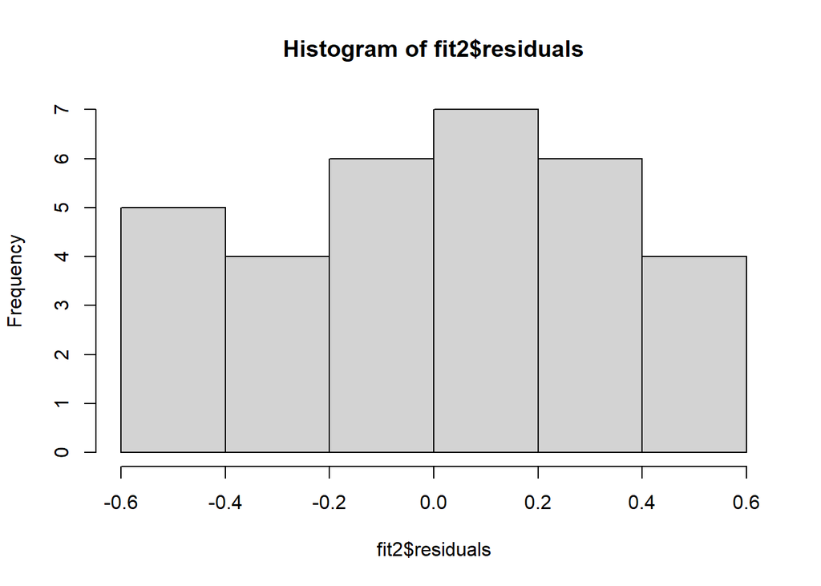

```r
fit2 <-lm(Shannon~Type, data=indice_diversite_unplanted)
hist(fit2$residuals) #suit une loi normale?
```

```r
shapiro.test(fit2$residuals)
```

```
##
##  Shapiro-Wilk normality test
##
## data:  fit2$residuals
## W = 0.93945, p-value = 0.07222
```

```r
glm_fit2 <- glm(Shannon~Type, data=indice_diversite_unplanted) #link="inverse" by default
summary(glm_fit2)
```

```
##
## Call:
## glm(formula = Shannon ~ Type, data = indice_diversite_unplanted)
##
## Deviance Residuals:
##      Min        1Q    Median        3Q       Max
## -0.59991  -0.24127   0.00934   0.22532   0.46449
##
## Coefficients:
##             Estimate Std. Error t value Pr(>|t|)
## (Intercept)  3.24275    0.12118  26.760   <2e-16 ***
## TypemiPEP-A -0.02769    0.17137  -0.162    0.873
## TypemiPEP-B -0.16209    0.17137  -0.946    0.352
## TypemiPEP-C -0.21446    0.17137  -1.251    0.221
## ---
## Signif. codes:  0 '***' 0.001 '**' 0.01 '*' 0.05 '.' 0.1 ' ' 1
##
## (Dispersion parameter for gaussian family taken to be 0.1174759)
##
##     Null deviance: 3.5468  on 31  degrees of freedom
## Residual deviance: 3.2893  on 28  degrees of freedom
## AIC: 28.01
##
## Number of Fisher Scoring iterations: 2
```

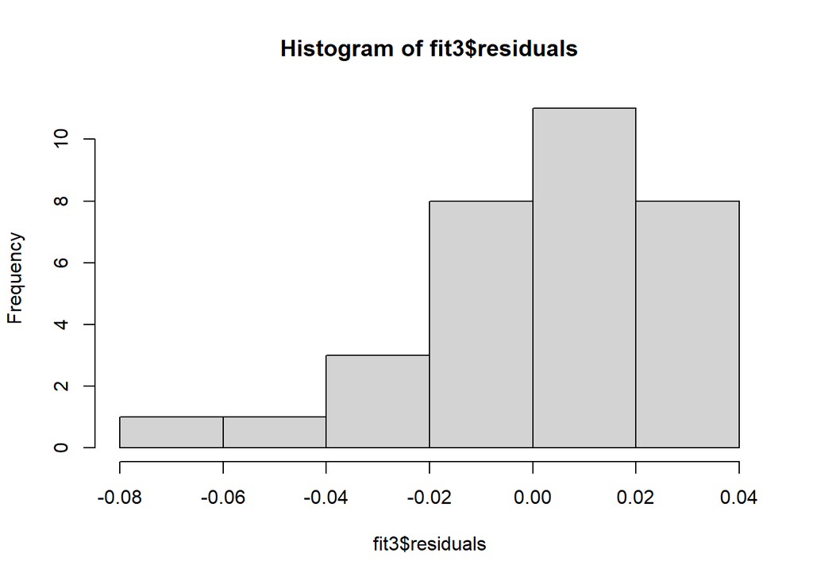

```r
fit3 <-lm(Simpson~Type, data=indice_diversite_unplanted)
hist(fit3$residuals) #suit une loi normale? if not normal try a GLM
```

```r
shapiro.test(fit3$residuals)
```

```
##
##  Shapiro-Wilk normality test
##
## data:  fit3$residuals
## W = 0.92723, p-value = 0.03281
```

```r
glm_fit3 <- glm(Simpson~Type, data=indice_diversite_unplanted) #link="inverse" by default
summary(glm_fit3)
```

```
##
## Call:
## glm(formula = Simpson ~ Type, data = indice_diversite_unplanted)
##
## Deviance Residuals:
##       Min         1Q     Median         3Q        Max
## -0.076478  -0.007996   0.001721   0.019515   0.036216
##
## Coefficients:
##              Estimate Std. Error t value Pr(>|t|)
## (Intercept)  0.941330   0.009131 103.096   <2e-16 ***
## TypemiPEP-A -0.003438   0.012913  -0.266   0.7920
## TypemiPEP-B -0.019208   0.012913  -1.488   0.1481
## TypemiPEP-C -0.022694   0.012913  -1.757   0.0898 .
## ---
## Signif. codes:  0 '***' 0.001 '**' 0.01 '*' 0.05 '.' 0.1 ' ' 1
##
## (Dispersion parameter for gaussian family taken to be 0.0006669414)
##
##     Null deviance: 0.021729  on 31  degrees of freedom
## Residual deviance: 0.018674  on 28  degrees of freedom
## AIC: -137.47
##
## Number of Fisher Scoring iterations: 2
```

Bray-Curtis in root samples…

```r
set.seed(711)

PCOA_Bray_roots <- ordinate(physeq = phylo_roots, method = "PCoA", distance="bray")
PCOA_Bray_roots
```

```
## $correction
## [1] "none" "1"
##
## $note
## [1] "No correction was applied to the negative eigenvalues"
##
## $values
##     Eigenvalues  Relative_eig Rel_corr_eig Broken_stick Cum_corr_eig
## 1   1.919165905  0.2644970112  0.260684251  0.140256109    0.2606843
## 2   1.000542073  0.1378934396  0.136179284  0.104541823    0.3968635
## 3   0.579041456  0.0798027592  0.079051526  0.086684680    0.4759151
## 4   0.456193627  0.0628720271  0.062401441  0.074779918    0.5383165
## 5   0.406840177  0.0560701973  0.055712360  0.065851347    0.5940289
## 6   0.336388113  0.0463605831  0.046163694  0.058708489    0.6401926
## 7   0.298298168  0.0411110752  0.041001203  0.052756109    0.6811938
## 8   0.257112005  0.0354348504  0.035419068  0.047654068    0.7166128
## 9   0.222725942  0.0306958068  0.030758580  0.043189782    0.7473714
## 10  0.201932297  0.0278300530  0.027940330  0.039221528    0.7753117
## 11  0.175663774  0.0242097585  0.024380046  0.035650099    0.7996918
## 12  0.171766220  0.0236726026  0.023851794  0.032403346    0.8235436
## 13  0.158730073  0.0218759774  0.022084950  0.029427156    0.8456285
## 14  0.136103700  0.0187576394  0.019018302  0.026679903    0.8646468
## 15  0.123555608  0.0170282772  0.017317606  0.024128883    0.8819644
## 16  0.112746809  0.0155386222  0.015852644  0.021747930    0.8978171
## 17  0.107046399  0.0147529989  0.015080043  0.019515787    0.9128971
## 18  0.094042751  0.0129608527  0.013317604  0.017414947    0.9262147
## 19  0.085480818  0.0117808579  0.012157169  0.015430820    0.9383719
## 20  0.074607674  0.0102823350  0.010683486  0.013551121    0.9490554
## 21  0.071353546  0.0098338552  0.010242440  0.011765406    0.9592978
## 22  0.064707270  0.0089178738  0.009341642  0.010064726    0.9686395
## 23  0.051349768  0.0070769599  0.007531244  0.008441350    0.9761707
## 24  0.042996579  0.0059257340  0.006399101  0.006888555    0.9825698
## 25  0.037561585  0.0051766900  0.005662473  0.005400459    0.9882323
## 26  0.036017608  0.0049639010  0.005453211  0.003971888    0.9936855
## 27  0.025389597  0.0034991621  0.004012752  0.002598262    0.9976982
## 28  0.012765512  0.0017593266  0.002301756  0.001275510    1.0000000
## 29  0.000000000  0.0000000000  0.000000000  0.000000000    1.0000000
## 30 -0.004217332 -0.0005812273  0.000000000  0.000000000    1.0000000
##    Cumul_br_stick
## 1       0.1402561
```

[output cut: 208 more lines]

```
## cR8    -0.022807089 -0.0954294963 -8.068118e-03
## ctrlR1 -0.060169979 -0.0015762643  1.086020e-02
## ctrlR2 -0.026964004  0.0388017266 -3.941409e-03
## ctrlR3  0.074205596  0.0572663128 -3.464831e-02
## ctrlR4 -0.007798647  0.0038033909 -2.051938e-02
## ctrlR5  0.005365921 -0.0298905557  1.123605e-02
## ctrlR6 -0.017083842 -0.0062324946  6.435244e-03
## ctrlR7  0.001129983 -0.0068052315  3.758327e-02
## ctrlR8 -0.010536224 -0.0019463312  1.095418e-02
##
## $trace
## [1] 7.255908
##
## attr(,"class")
## [1] "pcoa"
```

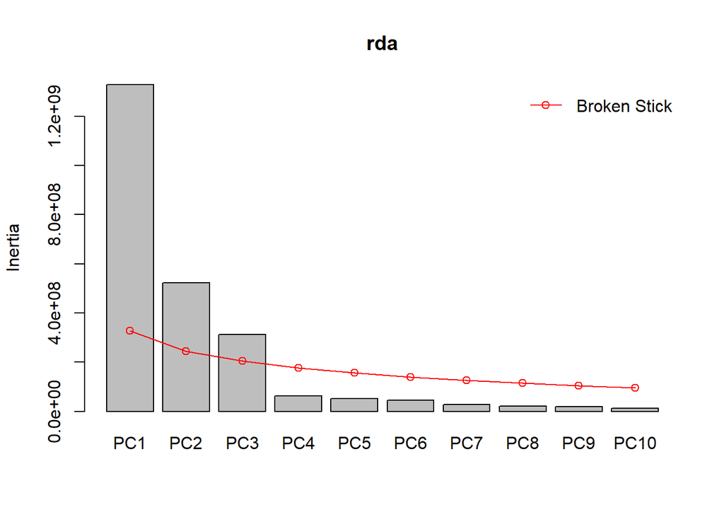

```r
# The 2 main axes: Relative_eig has to be > Broken_stick, i.e. more than just random interpretation OR at least cumul eig > cumul broken stick
otu_roots <- otu_table(phylo_roots)
rda <- rda(otu_roots) #raw data without the sample column which conflicts w/rda
screeplot(rda, bstick=TRUE)
```

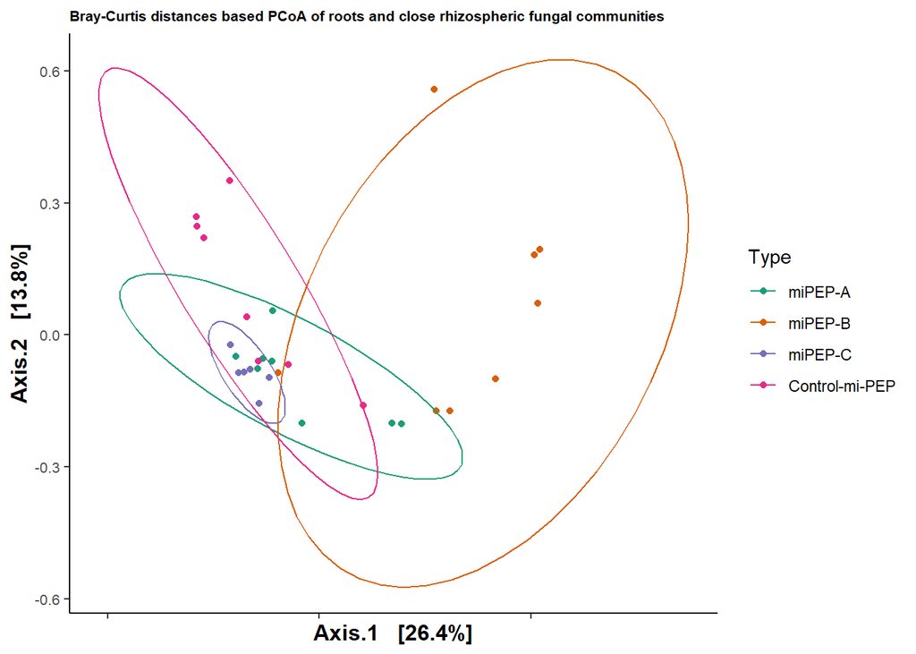

```r
#This graph shows that the first 3 axes are ok


bc_roots <- plot_ordination(physeq = phylo_roots, ordination=PCOA_Bray_roots, color="Type")+ theme_classic()+ theme(axis.text.y = element_text (), axis.text.x = element_blank (), axis.text =element_text(size=8), axis.title=element_text(size=12,face="bold"))+scale_color_manual(values=c("#1B9E77", "#D95F02", "#7570B3", "#E7298A", "#66A61E", "#E6AB02", "#A6761D","#666666"))+stat_ellipse()
bc_roots <- bc_roots + ggtitle("Bray-Curtis distances based PCoA of roots and close rhizospheric fungal communities") +theme(plot.title = element_text(size = 8, face = "bold"))
bc_roots
```

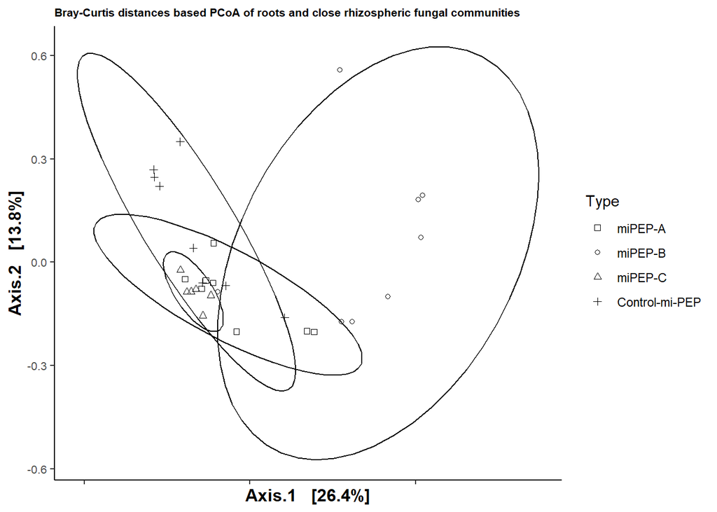

```r
# en noir et blanc avec des formes

bc_roots_nb <- plot_ordination(physeq = phylo_roots, ordination=PCOA_Bray_roots, shape="Type")+ theme_classic()+ theme(axis.text.y = element_text (), axis.text.x = element_blank (), axis.text =element_text(size=8), axis.title=element_text(size=12,face="bold"))+scale_shape_manual(values=c(0,1,2,3,19,15,8))+stat_ellipse()
bc_roots_nb  + ggtitle("Bray-Curtis distances based PCoA of roots and close rhizospheric fungal communities") +theme(plot.title = element_text(size = 8, face = "bold"))
```

```r
#Statistical analysis: permanova & beta-disper test
# Calculate bray curtis distance matrix
bray_roots <- phyloseq::distance(phylo_roots, method = "bray")
sampledf_roots <- data.frame(sample_data(phylo_roots))
adonis(bray_roots ~ Type, data = sampledf_roots)
```

```
## 'adonis' will be deprecated: use 'adonis2' instead
```

```
## $aov.tab
## Permutation: free
## Number of permutations: 999
##
## Terms added sequentially (first to last)
##
##           Df SumsOfSqs MeanSqs F.Model     R2 Pr(>F)
## Type       3    2.1006 0.70019  3.5313 0.2895  0.001 ***
## Residuals 26    5.1553 0.19828         0.7105
## Total     29    7.2559                 1.0000
## ---
## Signif. codes:  0 '***' 0.001 '**' 0.01 '*' 0.05 '.' 0.1 ' ' 1
##
## $call
## adonis(formula = bray_roots ~ Type, data = sampledf_roots)
```

[output cut: 1092 more lines]

```r
# If Type has a significant effect, check group dispersion
Disper_Type_roots = betadisper(bray_roots, sampledf_roots$Type)
permutest(Disper_Type_roots, pairwise=TRUE, permutations=1000)
```

```
##
## Permutation test for homogeneity of multivariate dispersions
## Permutation: free
## Number of permutations: 1000
##
## Response: Distances
##           Df  Sum Sq  Mean Sq      F N.Perm  Pr(>F)
## Groups     3 0.09705 0.032348 2.5889   1000 0.06194 .
## Residuals 26 0.32487 0.012495
## ---
## Signif. codes:  0 '***' 0.001 '**' 0.01 '*' 0.05 '.' 0.1 ' ' 1
##
## Pairwise comparisons:
## (Observed p-value below diagonal, permuted p-value above diagonal)
##                 miPEP-A  miPEP-B  miPEP-C Control-mi-PEP
## miPEP-A                 0.463536 0.031968         0.9121
## miPEP-B        0.438765          0.025974         0.3936
## miPEP-C        0.031170 0.035116                  0.0160
## Control-mi-PEP 0.912303 0.384156 0.027526
```

```r
#If the dispersion test is signif, it means that the Type effect is acutally only due to group dispersion, and not a real biological effect

#### Pairwise multilevel comparison using adonis #####
library(devtools)
```

```r
#install_github("pmartinezarbizu/pairwiseAdonis/pairwiseAdonis")

pairwise.adonis <- function(x,factors, sim.function = 'vegdist', sim.method = 'bray', p.adjust.m ='bonferroni',reduce=NULL,perm=999)
{

  co <- combn(unique(as.character(factors)),2)
  pairs <- c()
  Df <- c()
  SumsOfSqs <- c()
  F.Model <- c()
  R2 <- c()
  p.value <- c()


  for(elem in 1:ncol(co)){
    if(inherits(x, 'dist')){
      x1=as.matrix(x)[factors %in% c(as.character(co[1,elem]),as.character(co[2,elem])),
                      factors %in% c(as.character(co[1,elem]),as.character(co[2,elem]))]
    }

    else  (
      if (sim.function == 'daisy'){
        x1 = daisy(x[factors %in% c(co[1,elem],co[2,elem]),],metric=sim.method)
      }
      else{x1 = vegdist(x[factors %in% c(co[1,elem],co[2,elem]),],method=sim.method)}
    )

    ad <- adonis(x1 ~ factors[factors %in% c(co[1,elem],co[2,elem])],
                 permutations = perm);
    pairs <- c(pairs,paste(co[1,elem],'vs',co[2,elem]));
    Df <- c(Df,ad$aov.tab[1,1])
    SumsOfSqs <- c(SumsOfSqs, ad$aov.tab[1,2])
    F.Model <- c(F.Model,ad$aov.tab[1,4]);
    R2 <- c(R2,ad$aov.tab[1,5]);
    p.value <- c(p.value,ad$aov.tab[1,6])
  }
  p.adjusted <- p.adjust(p.value,method=p.adjust.m)

  sig = c(rep('',length(p.adjusted)))
  sig[p.adjusted <= 0.05] <-'.'
  sig[p.adjusted <= 0.01] <-'*'
  sig[p.adjusted <= 0.001] <-'**'
  sig[p.adjusted <= 0.0001] <-'***'
  pairw.res <- data.frame(pairs,Df,SumsOfSqs,F.Model,R2,p.value,p.adjusted,sig)

  if(!is.null(reduce)){
    pairw.res <- subset (pairw.res, grepl(reduce,pairs))
    pairw.res$p.adjusted <- p.adjust(pairw.res$p.value,method=p.adjust.m)

    sig = c(rep('',length(pairw.res$p.adjusted)))
    sig[pairw.res$p.adjusted <= 0.1] <-'.'
    sig[pairw.res$p.adjusted <= 0.05] <-'*'
    sig[pairw.res$p.adjusted <= 0.01] <-'**'
    sig[pairw.res$p.adjusted <= 0.001] <-'***'
    pairw.res <- data.frame(pairw.res[,1:7],sig)
  }
  class(pairw.res) <- c("pwadonis", "data.frame")
  return(pairw.res)
}


### Method summary
summary.pwadonis = function(object, ...) {
  cat("Result of pairwise.adonis:\n")
  cat("\n")
  print(object, ...)
  cat("\n")
  cat("Signif. codes:  0 '***' 0.001 '**' 0.01 '*' 0.05 '.' 0.1 ' ' 1\n")
}


pairwise.adonis(bray_roots, sampledf_roots$Type)
```

```
## 'adonis' will be deprecated: use 'adonis2' instead
```

```
## 'adonis' will be deprecated: use 'adonis2' instead
## 'adonis' will be deprecated: use 'adonis2' instead
## 'adonis' will be deprecated: use 'adonis2' instead
## 'adonis' will be deprecated: use 'adonis2' instead
## 'adonis' will be deprecated: use 'adonis2' instead
```

```
##                       pairs Df SumsOfSqs  F.Model        R2 p.value p.adjusted
## 1        miPEP-A vs miPEP-B  1 0.7970225 3.425395 0.1965749   0.001      0.006
## 2        miPEP-A vs miPEP-C  1 0.2180978 1.348170 0.1010003   0.098      0.588
## 3 miPEP-A vs Control-mi-PEP  1 0.5025703 2.557052 0.1544388   0.006      0.036
## 4        miPEP-B vs miPEP-C  1 1.0440522 5.212144 0.3028178   0.002      0.012
## 5 miPEP-B vs Control-mi-PEP  1 1.1848988 5.161257 0.2693590   0.001      0.006
## 6 miPEP-C vs Control-mi-PEP  1 0.3996518 2.527027 0.1739535   0.009      0.054
##   sig
## 1   *
## 2
## 3   .
## 4   .
## 5   *
## 6
```

Bray-Curtis in soil samples…

```r
set.seed(711)
PCOA_Bray_soil <- ordinate(physeq = phylo_soil, method = "PCoA", distance="bray")
PCOA_Bray_soil
```

```
## $correction
## [1] "none" "1"
##
## $note
## [1] "No correction was applied to the negative eigenvalues"
##
## $values
##     Eigenvalues Relative_eig Rel_corr_eig Broken_stick Cum_corr_eig
## 1   1.528528108  0.242696483  0.220036725  0.136608752    0.2200367
## 2   0.745110236  0.118307039  0.109110178  0.102125993    0.3291469
## 3   0.526405466  0.083581554  0.078143097  0.084884614    0.4072900
## 4   0.445727686  0.070771706  0.066719682  0.073390361    0.4740097
## 5   0.356289595  0.056570914  0.054055868  0.064769671    0.5280656
## 6   0.294319079  0.046731365  0.045281272  0.057873119    0.5733468
## 7   0.259036949  0.041129343  0.040285566  0.052125993    0.6136324
## 8   0.237980752  0.037786084  0.037304155  0.047199885    0.6509365
## 9   0.225112442  0.035742881  0.035482091  0.042889540    0.6864186
## 10  0.209008375  0.033185911  0.033201867  0.039058122    0.7196205
## 11  0.186119467  0.029551658  0.029960956  0.035609846    0.7495815
## 12  0.163411743  0.025946173  0.026745699  0.032475050    0.7763272
## 13  0.150921543  0.023963006  0.024977173  0.029601487    0.8013043
## 14  0.139852098  0.022205422  0.023409817  0.026948967    0.8247141
## 15  0.134744555  0.021394457  0.022686624  0.024485913    0.8474008
## 16  0.110057909  0.017474764  0.019191166  0.022187062    0.8665919
## 17  0.104451966  0.016584664  0.018397403  0.020031890    0.8849893
## 18  0.098735803  0.015677064  0.017588034  0.018003492    0.9025774
## 19  0.078657398  0.012489057  0.014745071  0.016087783    0.9173224
## 20  0.074118001  0.011768301  0.014102324  0.014272901    0.9314248
## 21  0.063970707  0.010157135  0.012665537  0.012548763    0.9440903
## 22  0.046378818  0.007363931  0.010174647  0.010906727    0.9542650
## 23  0.042638314  0.006770022  0.009645018  0.009339329    0.9639100
## 24  0.031853211  0.005057586  0.008117922  0.007840079    0.9720279
## 25  0.026238393  0.004166077  0.007322903  0.006403297    0.9793508
## 26  0.020457993  0.003248277  0.006504438  0.005023987    0.9858552
## 27  0.015967226  0.002535243  0.005868577  0.003697727    0.9917238
## 28  0.009310243  0.001478261  0.004925994  0.002420588    0.9966498
## 29  0.000000000  0.000000000  0.003350197  0.001189061    1.0000000
## 30 -0.001818811 -0.000288787  0.000000000  0.000000000    1.0000000
## 31 -0.025479550 -0.004045589  0.000000000  0.000000000    1.0000000
##    Cumul_br_stick
```

[output cut: 216 more lines]

```
## cS7     0.0306828941  0.0171216485 -0.0072569998
## cS8    -0.0364172741  0.0222498903  0.0496567990
## ctrlS1  0.0110254376 -0.0272484060  0.0071425747
## ctrlS2  0.0361664697  0.0326051328  0.0195795229
## ctrlS3 -0.0610598910 -0.0089653469 -0.0012703085
## ctrlS4  0.0488730319  0.0118090646 -0.0198252015
## ctrlS5  0.0154688784  0.0196521627  0.0179172487
## ctrlS7 -0.0185636846  0.0033110906  0.0257099386
## ctrlS8 -0.0006119610  0.0062623077 -0.0099233953
##
## $trace
## [1] 6.298106
##
## attr(,"class")
## [1] "pcoa"
```

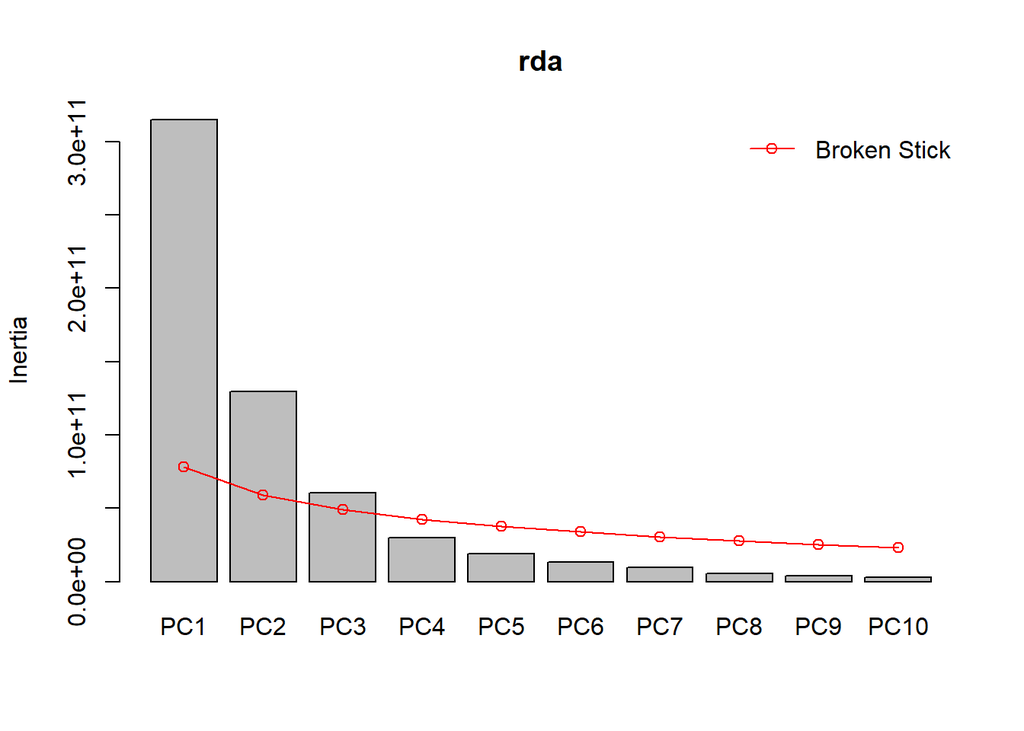

```r
# The 2 main axes: Relative_eig has to be > Broken_stick, i.e. more than just random interpretation OR at least cumul eig > cumul broken stick
otu_soil <- otu_table(phylo_soil)
rda <- rda(otu_soil) #raw data without the sample column which conflicts w/rda
screeplot(rda, bstick=TRUE)
```

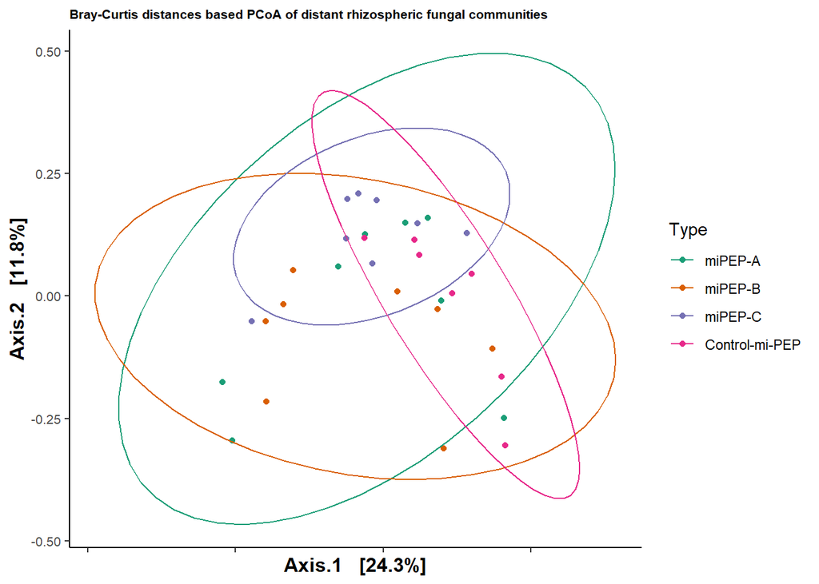

```r
#This graph shows that the 3 first axes are > random


bc_soil <- plot_ordination(physeq = phylo_soil, ordination=PCOA_Bray_soil, color="Type")+ theme_classic()+ theme(axis.text.y = element_text (), axis.text.x = element_blank (), axis.text =element_text(size=8), axis.title=element_text(size=12,face="bold"))+scale_color_manual(values=c("#1B9E77", "#D95F02", "#7570B3", "#E7298A", "#66A61E", "#E6AB02", "#A6761D","#666666"))+stat_ellipse()
bc_soil <- bc_soil + ggtitle("Bray-Curtis distances based PCoA of distant rhizospheric fungal communities") +theme(plot.title = element_text(size = 8, face = "bold"))
bc_soil
```

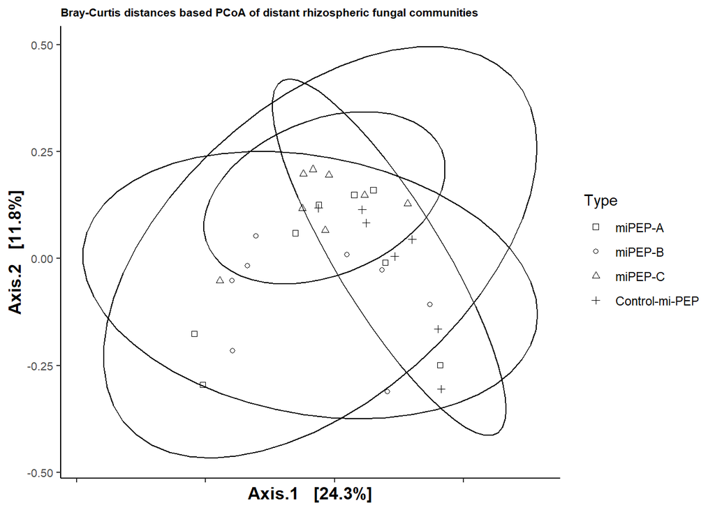

```r
# en noir et blanc avec des formes
bc_soil_nb <- plot_ordination(physeq = phylo_soil, ordination=PCOA_Bray_soil, shape="Type")+ theme_classic()+ theme(axis.text.y = element_text (), axis.text.x = element_blank (), axis.text =element_text(size=8), axis.title=element_text(size=12,face="bold"))+scale_shape_manual(values=c(0,1,2,3,19,15,8))+stat_ellipse()
bc_soil_nb <- bc_soil_nb  + ggtitle("Bray-Curtis distances based PCoA of distant rhizospheric fungal communities") +theme(plot.title = element_text(size = 8, face = "bold"))
bc_soil_nb
```

```r
#Statistical analysis: permanova & beta-disper test
# Calculate bray curtis distance matrix
bray_soil <- phyloseq::distance(phylo_soil, method = "bray")
sampledf_soil <- data.frame(sample_data(phylo_soil))
adonis(bray_soil ~ Type, data = sampledf_soil)
```

```
## 'adonis' will be deprecated: use 'adonis2' instead
```

```
## $aov.tab
## Permutation: free
## Number of permutations: 999
##
## Terms added sequentially (first to last)
##
##           Df SumsOfSqs MeanSqs F.Model      R2 Pr(>F)
## Type       3    1.1068 0.36892  1.9187 0.17573  0.002 **
## Residuals 27    5.1913 0.19227         0.82427
## Total     30    6.2981                 1.00000
## ---
## Signif. codes:  0 '***' 0.001 '**' 0.01 '*' 0.05 '.' 0.1 ' ' 1
##
## $call
## adonis(formula = bray_soil ~ Type, data = sampledf_soil)
```

[output cut: 1098 more lines]

```r
# If Type has a significant effect, check group dispersion
Disper_Type_soil = betadisper(bray_soil, sampledf_soil$Type)
permutest(Disper_Type_soil, pairwise=TRUE, permutations=1000)
```

```
##
## Permutation test for homogeneity of multivariate dispersions
## Permutation: free
## Number of permutations: 1000
##
## Response: Distances
##           Df  Sum Sq  Mean Sq      F N.Perm   Pr(>F)
## Groups     3 0.12087 0.040290 6.0626   1000 0.002997 **
## Residuals 27 0.17944 0.006646
## ---
## Signif. codes:  0 '***' 0.001 '**' 0.01 '*' 0.05 '.' 0.1 ' ' 1
##
## Pairwise comparisons:
## (Observed p-value below diagonal, permuted p-value above diagonal)
##                  miPEP-A   miPEP-B   miPEP-C Control-mi-PEP
## miPEP-A                  0.1128871 0.0019980         0.0180
## miPEP-B        0.0993055           0.0469530         0.3666
## miPEP-C        0.0011004 0.0496935                   0.2038
## Control-mi-PEP 0.0119615 0.3585930 0.2010277
```

```r
#If the dispersion test is signif, it means that the Type effect is acutally only due to group dispersion, and not a real biological effect

pairwise.adonis(bray_soil, sampledf_soil$Type)
```

```
## 'adonis' will be deprecated: use 'adonis2' instead
## 'adonis' will be deprecated: use 'adonis2' instead
## 'adonis' will be deprecated: use 'adonis2' instead
## 'adonis' will be deprecated: use 'adonis2' instead
## 'adonis' will be deprecated: use 'adonis2' instead
## 'adonis' will be deprecated: use 'adonis2' instead
```

```
##                       pairs Df SumsOfSqs  F.Model         R2 p.value p.adjusted
## 1        miPEP-A vs miPEP-B  1 0.3563448 1.490594 0.09622577   0.090      0.540
## 2        miPEP-A vs miPEP-C  1 0.3317982 1.656109 0.10578040   0.054      0.324
## 3 miPEP-A vs Control-mi-PEP  1 0.4190770 1.855773 0.12491934   0.019      0.114
## 4        miPEP-B vs miPEP-C  1 0.3213615 1.994582 0.12470360   0.038      0.228
## 5 miPEP-B vs Control-mi-PEP  1 0.3798761 2.069326 0.13732039   0.040      0.240
## 6 miPEP-C vs Control-mi-PEP  1 0.4115490 2.900632 0.18242243   0.003      0.018
##   sig
## 1
## 2
## 3
## 4
## 5
## 6   .
```

Bray-Curtis in unplanted samples…

```r
set.seed(711)
PCOA_Bray_unplanted <- ordinate(physeq = phylo_unplanted, method = "PCoA", distance="bray")
PCOA_Bray_unplanted
```

```
## $correction
## [1] "none" "1"
##
## $note
## [1] "No correction was applied to the negative eigenvalues"
##
## $values
##     Eigenvalues  Relative_eig Rel_corr_eig Broken_stick Cum_corr_eig
## 1   2.426705247  0.3205157125 0.3076419061  0.133166238    0.3076419
## 2   0.945221483  0.1248434838 0.1207085483  0.099832904    0.4283505
## 3   0.562145441  0.0742473552 0.0723720815  0.083166238    0.5007225
## 4   0.472634381  0.0624248641 0.0610775918  0.072055127    0.5618001
## 5   0.392254439  0.0518083979 0.0509352651  0.063721793    0.6127354
## 6   0.327676315  0.0432790128 0.0427868089  0.057055127    0.6555222
## 7   0.281071735  0.0371235475 0.0369062513  0.051499571    0.6924285
## 8   0.259140858  0.0342269490 0.0341390171  0.046737666    0.7265675
## 9   0.202781776  0.0267831231 0.0270276381  0.042571000    0.7535951
## 10  0.188399612  0.0248835478 0.0252128993  0.038867296    0.7788080
## 11  0.176980498  0.0233753277 0.0237720375  0.035533963    0.8025800
## 12  0.169887113  0.0224384437 0.0228769954  0.032503660    0.8254570
## 13  0.148954315  0.0196736701 0.0202356988  0.029725882    0.8456927
## 14  0.140946753  0.0186160429 0.0192253060  0.027161779    0.8649180
## 15  0.133571051  0.0176418709 0.0182946413  0.024780827    0.8832127
## 16  0.125392247  0.0165616263 0.0172626412  0.022558605    0.9004753
## 17  0.107495941  0.0141979081 0.0150044885  0.020475271    0.9154798
## 18  0.087828323  0.0116002376 0.0125228319  0.018514487    0.9280026
## 19  0.076974331  0.0101666581 0.0111532772  0.016662635    0.9391559
## 20  0.074437781  0.0098316343 0.0108332158  0.014908249    0.9499891
## 21  0.067210461  0.0088770603 0.0099212738  0.013241582    0.9599104
## 22  0.059308457  0.0078333750 0.0089242003  0.011654281    0.9688346
## 23  0.046591301  0.0061537116 0.0073195519  0.010139129    0.9761542
## 24  0.035584796  0.0046999882 0.0059307529  0.008689854    0.9820849
## 25  0.034348985  0.0045367641 0.0057748185  0.007300965    0.9878597
## 26  0.015399716  0.0020339721 0.0033838031  0.005967632    0.9912435
## 27  0.013199367  0.0017433533 0.0031061636  0.004685580    0.9943497
## 28  0.009482175  0.0012523919 0.0026371289  0.003451013    0.9969868
## 29  0.004863001  0.0006422981 0.0020542823  0.002260536    0.9990411
## 30  0.000000000  0.0000000000 0.0009588837  0.001111111    1.0000000
## 31 -0.003818250 -0.0005043089 0.0000000000  0.000000000    1.0000000
## 32 -0.011417592 -0.0015080190 0.0000000000  0.000000000    1.0000000
```

[output cut: 224 more lines]

```
## cSN8     2.709298e-02  0.026865730 -0.0230329645  0.0195665940
## ctrlSN1 -1.560629e-02  0.023478216  0.0069119827  0.0037167849
## ctrlSN2  9.683265e-05  0.009998263 -0.0011959758  0.0017707708
## ctrlSN3  7.817006e-03 -0.006760764 -0.0113249460 -0.0003805539
## ctrlSN4 -9.560819e-03 -0.024050663  0.0155809351  0.0217056861
## ctrlSN5  3.744508e-02 -0.038530652 -0.0052769538 -0.0124366894
## ctrlSN6  2.212833e-02 -0.036289938 -0.0194535761 -0.0144788469
## ctrlSN7  2.363870e-03 -0.013126505 -0.0055037238 -0.0014353708
## ctrlSN8  1.847895e-03 -0.003519680  0.0014356059 -0.0032159056
##
## $trace
## [1] 7.571252
##
## attr(,"class")
## [1] "pcoa"
```

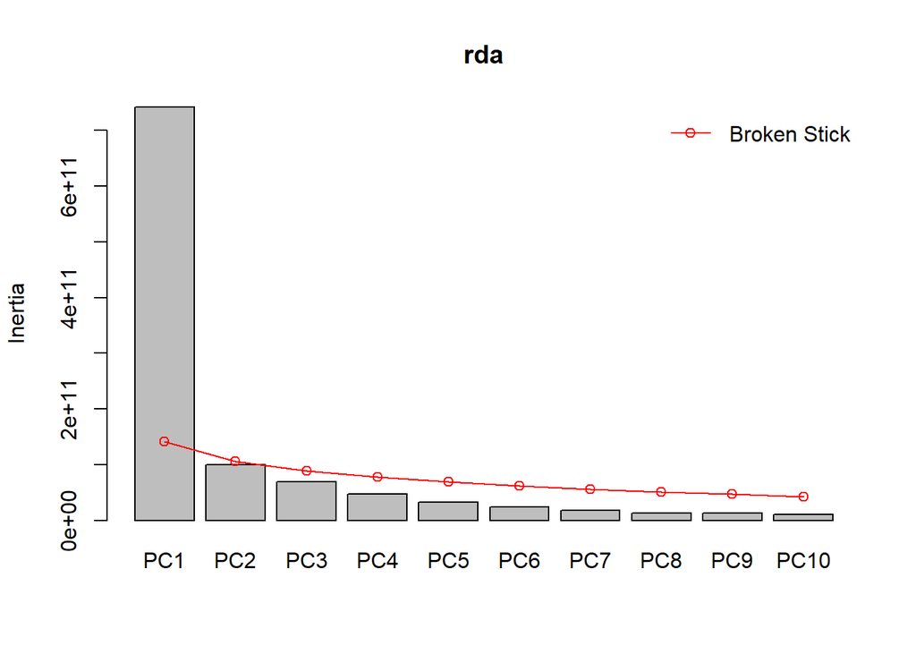

```r
# The 2 main axes: Relative_eig has to be > Broken_stick, i.e. more than just random interpretation OR at least cumul eig > cumul broken stick
otu_unplanted <- otu_table(phylo_unplanted)
rda <- rda(otu_unplanted) #raw data without the sample column which conflicts w/rda
screeplot(rda, bstick=TRUE)
```

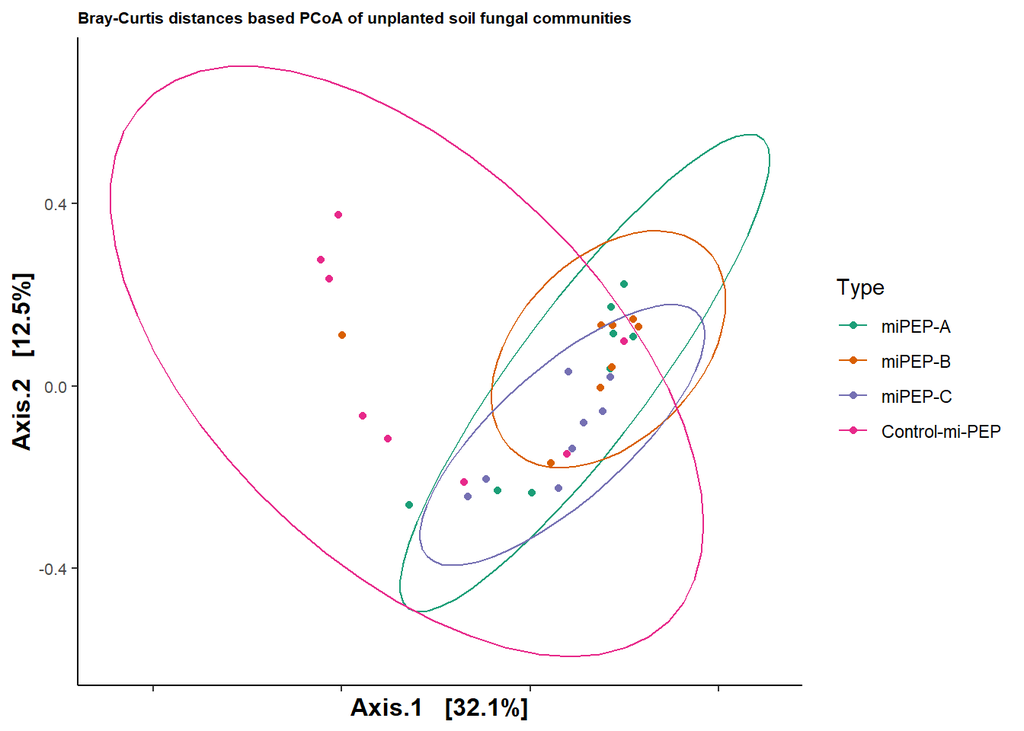

```r
#This graph shows that the 2nd axis is not interpretable

bc_unplanted <- plot_ordination(physeq = phylo_unplanted, ordination=PCOA_Bray_unplanted, color="Type")+ theme_classic()+ theme(axis.text.y = element_text (), axis.text.x = element_blank (), axis.text =element_text(size=8), axis.title=element_text(size=12,face="bold"))+scale_color_manual(values=c("#1B9E77", "#D95F02", "#7570B3", "#E7298A", "#66A61E", "#E6AB02", "#A6761D","#666666"))+stat_ellipse()
bc_unplanted <- bc_unplanted + ggtitle("Bray-Curtis distances based PCoA of unplanted soil fungal communities") +theme(plot.title = element_text(size = 8, face = "bold"))
bc_unplanted
```

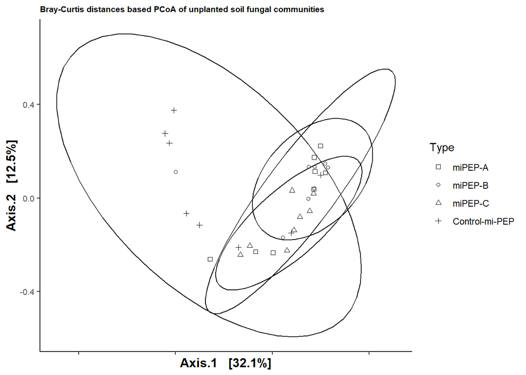

```r
# en noir et blanc avec des formes
bc_unplanted_nb <- plot_ordination(physeq = phylo_unplanted, ordination=PCOA_Bray_unplanted, shape="Type")+ theme_classic()+ theme(axis.text.y = element_text (), axis.text.x = element_blank (), axis.text =element_text(size=8), axis.title=element_text(size=12,face="bold"))+scale_shape_manual(values=c(0,1,2,3,19,15,8))+stat_ellipse()
bc_unplanted_nb <- bc_unplanted_nb  + ggtitle("Bray-Curtis distances based PCoA of unplanted soil fungal communities") +theme(plot.title = element_text(size = 8, face = "bold"))
bc_unplanted_nb
```

```r
#Statistical analysis: permanova & beta-disper test
# Calculate bray curtis distance matrix
bray_unplanted <- phyloseq::distance(phylo_unplanted, method = "bray")
sampledf_unplanted <- data.frame(sample_data(phylo_unplanted))
adonis(bray_unplanted ~ Type, data = sampledf_unplanted)
```

```
## 'adonis' will be deprecated: use 'adonis2' instead
```

```
## $aov.tab
## Permutation: free
## Number of permutations: 999
##
## Terms added sequentially (first to last)
##
##           Df SumsOfSqs MeanSqs F.Model      R2 Pr(>F)
## Type       3    1.4756 0.49186  2.2593 0.19489  0.004 **
## Residuals 28    6.0957 0.21770         0.80511
## Total     31    7.5713                 1.00000
## ---
## Signif. codes:  0 '***' 0.001 '**' 0.01 '*' 0.05 '.' 0.1 ' ' 1
##
## $call
## adonis(formula = bray_unplanted ~ Type, data = sampledf_unplanted)
```

[output cut: 1099 more lines]

```r
# If Type has a significant effect, check group dispersion
Disper_Type_unplanted = betadisper(bray_unplanted, sampledf_unplanted$Type)
permutest(Disper_Type_unplanted, pairwise=TRUE, permutations=1000)
```

```
##
## Permutation test for homogeneity of multivariate dispersions
## Permutation: free
## Number of permutations: 1000
##
## Response: Distances
##           Df  Sum Sq  Mean Sq      F N.Perm Pr(>F)
## Groups     3 0.05473 0.018243 1.1912   1000 0.3526
## Residuals 28 0.42881 0.015315
##
## Pairwise comparisons:
## (Observed p-value below diagonal, permuted p-value above diagonal)
##                 miPEP-A  miPEP-B  miPEP-C Control-mi-PEP
## miPEP-A                 0.536464 0.161838         0.5984
## miPEP-B        0.528868          0.673327         0.2667
## miPEP-C        0.165579 0.664786                  0.0340
## Control-mi-PEP 0.619754 0.286303 0.034531
```

```r
#If the dispersion test is signif, it means that the Type effect is acutally only due to group dispersion, and not a real biological effect

pairwise.adonis(bray_unplanted, sampledf_unplanted$Type)
```

```
## 'adonis' will be deprecated: use 'adonis2' instead
## 'adonis' will be deprecated: use 'adonis2' instead
## 'adonis' will be deprecated: use 'adonis2' instead
## 'adonis' will be deprecated: use 'adonis2' instead
## 'adonis' will be deprecated: use 'adonis2' instead
## 'adonis' will be deprecated: use 'adonis2' instead
```

```
##                       pairs Df SumsOfSqs  F.Model         R2 p.value p.adjusted
## 1        miPEP-A vs miPEP-B  1 0.2280382 1.028085 0.06841088   0.392      1.000
## 2        miPEP-A vs miPEP-C  1 0.2594753 1.297119 0.08479500   0.177      1.000
## 3 miPEP-A vs Control-mi-PEP  1 0.7352953 2.912475 0.17220866   0.011      0.066
## 4        miPEP-B vs miPEP-C  1 0.2628367 1.436734 0.09307242   0.098      0.588
## 5 miPEP-B vs Control-mi-PEP  1 0.7435514 3.159143 0.18410846   0.020      0.120
## 6 miPEP-C vs Control-mi-PEP  1 0.7219813 3.380130 0.19448243   0.009      0.054
##   sig
## 1
## 2
## 3
## 4
## 5
## 6
```

Weighted UniFrac : first, add phylogenetic tree

```r
library("ape")
library(magrittr)

pick_new_outgroup <- function(tree.unrooted){
  require("magrittr")
  require("data.table")
  require("ape") # ape::Ntip
  # tablify parts of tree that we need.
  treeDT <-
    cbind(
      data.table(tree.unrooted$edge),
      data.table(length = tree.unrooted$edge.length)
    )[1:Ntip(tree.unrooted)] %>%
    cbind(data.table(id = tree.unrooted$tip.label))
  # Take the longest terminal branch as outgroup
  new.outgroup <- treeDT[which.max(length)]$id
  return(new.outgroup) }

tree <- read.tree("~/metabarcoding_miPEP_mutants/ITS/ITS/plaque2/export/tree/tree.fasttree")
tree
```

```
##
## Phylogenetic tree with 1003 tips and 822 internal nodes.
##
## Tip labels:
##   418, 62, 300, 16, 227, 968, ...
## Node labels:
##   , 0.001, 0.669, 0.119, 0.858, 0.445, ...
##
## Unrooted; includes branch lengths.
```

```r
my.tree <- phy_tree(tree)
out.group <- pick_new_outgroup(my.tree)
out.group #ex : [1] "3312"
```

```
## [1] "568"
```

```r
new.tree <- ape::root(my.tree, outgroup=out.group, resolve.root=TRUE)#root tree to always have the same PCoA at each re-run
new.tree
```

```
##
## Phylogenetic tree with 1003 tips and 823 internal nodes.
##
## Tip labels:
##   418, 62, 300, 16, 227, 968, ...
## Node labels:
##   Root, , 0.001, 0.669, 0.119, 0.858, ...
##
## Rooted; includes branch lengths.
```

```r
#use the latest phyloseq info (-c2R, c7R, ctrlS6)
phylo_for_UniFrac <- phyloseq(tax_table,OTU_table,samples_final, new.tree)
phylo_for_UniFrac
```

```
## phyloseq-class experiment-level object
## otu_table()   OTU Table:         [ 320 taxa and 93 samples ]
## sample_data() Sample Data:       [ 93 samples by 4 sample variables ]
## tax_table()   Taxonomy Table:    [ 320 taxa by 12 taxonomic ranks ]
## phy_tree()    Phylogenetic Tree: [ 320 tips and 273 internal nodes ]
```

Subsample the UniFrac phyloseq object

```r
correct.order <- c("miPEP-A","miPEP-B","miPEP-C","Control-mi-PEP")
sample_data(phylo_for_UniFrac)$Type <- factor(sample_data(phylo_for_UniFrac)$Type, levels = correct.order)
levels(get_variable(phylo_for_UniFrac, "Type")) #mettre dans le bon ordre
```

```
## [1] "miPEP-A"        "miPEP-B"        "miPEP-C"        "Control-mi-PEP"
```

```r
phylo_for_UniFrac_soil <- subset_samples(phylo_for_UniFrac, Compartment=="SOL")
phylo_for_UniFrac_roots <- subset_samples(phylo_for_UniFrac, Compartment=="RACINE")
phylo_for_UniFrac_unplanted <- subset_samples(phylo_for_UniFrac, Compartment=="SOL.NU")
```

Weighted UniFrac in root samples…

```r
set.seed(711)
PCOA_weighted_roots <- ordinate(physeq = phylo_for_UniFrac_roots,  method = "PCoA", distance="unifrac", weighted=TRUE)
PCOA_weighted_roots
```

```
## $correction
## [1] "none" "1"
##
## $note
## [1] "No correction was applied to the negative eigenvalues"
##
## $values
##      Eigenvalues  Relative_eig Rel_corr_eig Broken_stick Cum_corr_eig
## 1   3.259520e-02  0.2315228592  0.193473635  0.140256109    0.1934736
## 2   2.026466e-02  0.1439393537  0.122802851  0.104541823    0.3162765
## 3   1.499584e-02  0.1065150605  0.092605338  0.086684680    0.4088818
## 4   9.468772e-03  0.0672564494  0.060927720  0.074779918    0.4698095
## 5   8.154270e-03  0.0579195779  0.053393835  0.065851347    0.5232034
## 6   7.590766e-03  0.0539170205  0.050164188  0.058708489    0.5733676
## 7   7.223572e-03  0.0513088534  0.048059668  0.052756109    0.6214272
## 8   5.815904e-03  0.0413102218  0.039991812  0.047654068    0.6614190
## 9   5.350508e-03  0.0380045251  0.037324458  0.043189782    0.6987435
## 10  4.757081e-03  0.0337894298  0.033923314  0.039221528    0.7326668
## 11  4.293555e-03  0.0304970121  0.031266676  0.035650099    0.7639335
## 12  4.146304e-03  0.0294510903  0.030422725  0.032403346    0.7943562
## 13  3.325475e-03  0.0236207633  0.025718258  0.029427156    0.8200745
## 14  2.738919e-03  0.0194544761  0.022356497  0.026679903    0.8424310
## 15  2.310023e-03  0.0164080358  0.019898336  0.024128883    0.8623293
## 16  2.030707e-03  0.0144240622  0.018297476  0.021747930    0.8806268
## 17  1.884294e-03  0.0133840913  0.017458328  0.019515787    0.8980851
## 18  1.587411e-03  0.0112753441  0.015756788  0.017414947    0.9138419
## 19  1.243702e-03  0.0088339849  0.013786865  0.015430820    0.9276288
## 20  1.072068e-03  0.0076148739  0.012803169  0.013551121    0.9404319
## 21  8.252978e-04  0.0058620694  0.011388838  0.011765406    0.9518208
## 22  6.567124e-04  0.0046646119  0.010422614  0.010064726    0.9622434
## 23  5.317425e-04  0.0037769536  0.009706366  0.008441350    0.9719498
## 24  2.744033e-04  0.0019490796  0.008231462  0.006888555    0.9801812
## 25  1.003996e-04  0.0007131355  0.007234184  0.005400459    0.9874154
## 26  6.046878e-05  0.0004295082  0.007005326  0.003971888    0.9944207
## 27  0.000000e+00  0.0000000000  0.003785446  0.002598262    0.9982062
## 28 -5.013313e-04 -0.0035609438  0.001793829  0.001275510    1.0000000
## 29 -8.488258e-04 -0.0060291884  0.000000000  0.000000000    1.0000000
## 30 -1.161811e-03 -0.0082523114  0.000000000  0.000000000    1.0000000
##    Cumul_br_stick
## 1       0.1402561
```

[output cut: 208 more lines]

```
## cR8     7.724505e-04
## ctrlR1  4.049837e-04
## ctrlR2 -1.264881e-03
## ctrlR3  1.027854e-03
## ctrlR4  1.427069e-03
## ctrlR5  1.166430e-03
## ctrlR6 -1.835228e-03
## ctrlR7 -2.558826e-03
## ctrlR8 -4.826662e-04
##
## $trace
## [1] 0.1407861
##
## attr(,"class")
## [1] "pcoa"
```

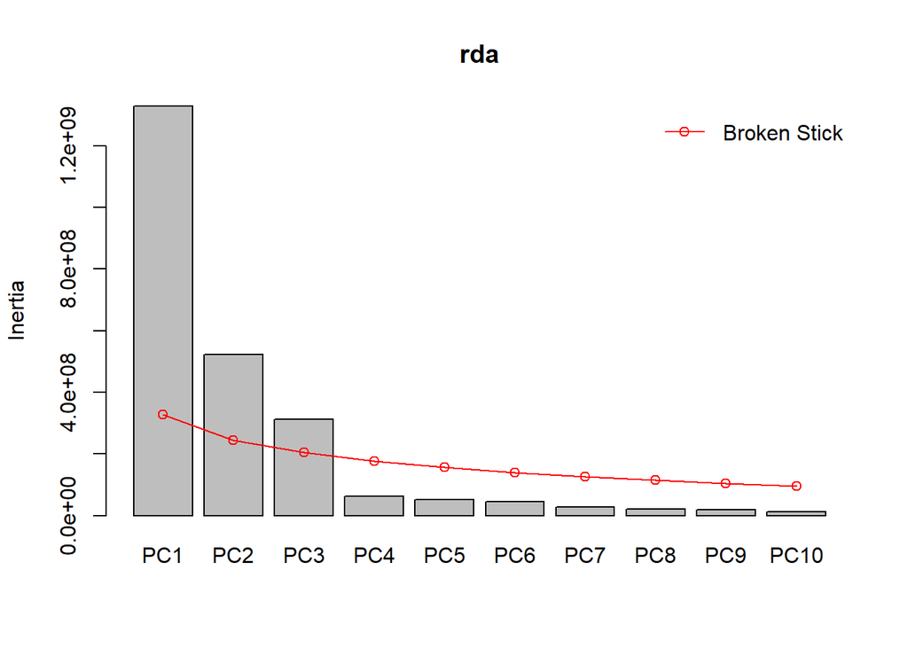

```r
# The 2 main axes: Relative_eig has to be > Broken_stick, i.e. more than just random interpretation OR at least cumul eig > cumul broken stick
otu_w_roots <- otu_table(phylo_for_UniFrac_roots)
rda <- rda(otu_w_roots) #raw data without the sample column which conflicts w/rda
screeplot(rda, bstick=TRUE)
```

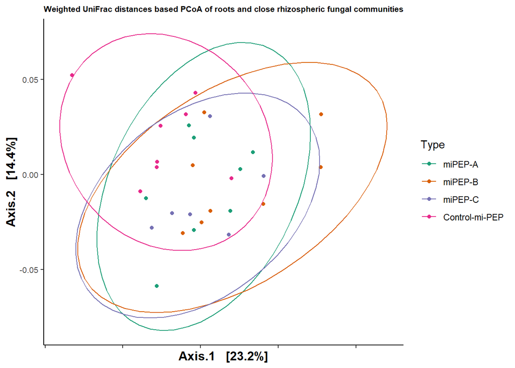

```r
#This graph shows that the 3 first axes are > random


WUF_roots <- plot_ordination(physeq = phylo_for_UniFrac_roots, ordination=PCOA_weighted_roots, color="Type")+ theme_classic()+ theme(axis.text.y = element_text (), axis.text.x = element_blank (), axis.text =element_text(size=8), axis.title=element_text(size=12,face="bold"))+scale_color_manual(values=c("#1B9E77", "#D95F02", "#7570B3", "#E7298A", "#66A61E", "#E6AB02", "#A6761D","#666666"))+stat_ellipse()
WUF_roots <- WUF_roots + ggtitle("Weighted UniFrac distances based PCoA of roots and close rhizospheric fungal communities") +theme(plot.title = element_text(size = 8, face = "bold"))
WUF_roots
```

```r
# en noir et blanc avec des formes
WUF_roots_nb <- plot_ordination(physeq = phylo_for_UniFrac_roots, ordination=PCOA_weighted_roots, shape="Type")+ theme_classic()+ theme(axis.text.y = element_text (), axis.text.x = element_blank (), axis.text =element_text(size=8), axis.title=element_text(size=12,face="bold"))+scale_shape_manual(values=c(0,1,2,3,19,15,8))+stat_ellipse()
WUF_roots_nb <- WUF_roots_nb  + ggtitle("Weighted UniFrac distances based PCoA of roots and close rhizospheric fungal communities") +theme(plot.title = element_text(size = 8, face = "bold"))

#Statistical analysis: permanova & beta-disper test

# Calculate distance matrix
WUF_roots <- phyloseq::distance(phylo_for_UniFrac_roots, method = "unifrac", weighted=TRUE)
sampledf_roots <- data.frame(sample_data(phylo_for_UniFrac_roots))
adonis(WUF_roots ~ Type, data = sampledf_roots)
```

```
## 'adonis' will be deprecated: use 'adonis2' instead
```

```
## $aov.tab
## Permutation: free
## Number of permutations: 999
##
## Terms added sequentially (first to last)
##
##           Df SumsOfSqs   MeanSqs F.Model      R2 Pr(>F)
## Type       3  0.022736 0.0075787  1.4541 0.14367  0.032 *
## Residuals 26  0.135511 0.0052120         0.85633
## Total     29  0.158247                   1.00000
## ---
## Signif. codes:  0 '***' 0.001 '**' 0.01 '*' 0.05 '.' 0.1 ' ' 1
##
## $call
## adonis(formula = WUF_roots ~ Type, data = sampledf_roots)
```

[output cut: 1092 more lines]

```r
# If Type has a significant effect, check group dispersion
Disper_Type_roots = betadisper(WUF_roots, sampledf_roots$Type)
permutest(Disper_Type_roots, pairwise=TRUE, permutations=1000)
```

```
##
## Permutation test for homogeneity of multivariate dispersions
## Permutation: free
## Number of permutations: 1000
##
## Response: Distances
##           Df    Sum Sq    Mean Sq      F N.Perm Pr(>F)
## Groups     3 0.0033895 0.00112983 1.6961   1000 0.1838
## Residuals 26 0.0173192 0.00066612
##
## Pairwise comparisons:
## (Observed p-value below diagonal, permuted p-value above diagonal)
##                 miPEP-A  miPEP-B  miPEP-C Control-mi-PEP
## miPEP-A                 0.747253 0.220779         0.1279
## miPEP-B        0.721119          0.108891         0.0779
## miPEP-C        0.223277 0.111984                  0.6913
## Control-mi-PEP 0.131303 0.092346 0.694609
```

```r
#If the dispersion test is signif, it means that the Type effect is acutally only due to group dispersion, and not a real biological effect

pairwise.adonis(WUF_roots, sampledf_roots$Type)
```

```
## 'adonis' will be deprecated: use 'adonis2' instead
## 'adonis' will be deprecated: use 'adonis2' instead
## 'adonis' will be deprecated: use 'adonis2' instead
## 'adonis' will be deprecated: use 'adonis2' instead
## 'adonis' will be deprecated: use 'adonis2' instead
## 'adonis' will be deprecated: use 'adonis2' instead
```

```
##                       pairs Df   SumsOfSqs   F.Model         R2 p.value
## 1        miPEP-A vs miPEP-B  1 0.005652652 0.8573055 0.05770262   0.588
## 2        miPEP-A vs miPEP-C  1 0.004380326 0.7399401 0.05808035   0.833
## 3 miPEP-A vs Control-mi-PEP  1 0.008448202 1.5539523 0.09990723   0.043
## 4        miPEP-B vs miPEP-C  1 0.004209921 0.8505035 0.06618445   0.582
## 5 miPEP-B vs Control-mi-PEP  1 0.012858067 2.7920587 0.16627257   0.005
## 6 miPEP-C vs Control-mi-PEP  1 0.009319806 2.5887084 0.17744603   0.005
##   p.adjusted sig
## 1      1.000
## 2      1.000
## 3      0.258
## 4      1.000
## 5      0.030   .
## 6      0.030   .
```

Weighted UniFrac in soil samples…

```r
set.seed(711)
PCOA_weighted_soil <- ordinate(physeq = phylo_for_UniFrac_soil,  method = "PCoA", distance="unifrac", weighted=TRUE)
PCOA_weighted_soil
```

```
## $correction
## [1] "none" "1"
##
## $note
## [1] "No correction was applied to the negative eigenvalues"
##
## $values
##      Eigenvalues  Relative_eig Rel_corr_eig Broken_stick Cum_corr_eig
## 1   4.769797e-02  0.2621651115  0.179570143  0.136608752    0.1795701
## 2   2.921708e-02  0.1605874990  0.114656143  0.102125993    0.2942263
## 3   2.564580e-02  0.1409584729  0.102112055  0.084884614    0.3963383
## 4   1.940457e-02  0.1066544271  0.080189775  0.073390361    0.4765281
## 5   1.695804e-02  0.0932074244  0.071596358  0.064769671    0.5481245
## 6   1.067150e-02  0.0586543665  0.049514946  0.057873119    0.5976394
## 7   6.069615e-03  0.0333607716  0.033350868  0.052125993    0.6309903
## 8   5.749523e-03  0.0316014312  0.032226547  0.047199885    0.6632168
## 9   4.966189e-03  0.0272959502  0.029475095  0.042889540    0.6926919
## 10  4.136446e-03  0.0227353870  0.026560629  0.039058122    0.7192526
## 11  3.984895e-03  0.0219024057  0.026028306  0.035609846    0.7452809
## 12  2.881699e-03  0.0158388446  0.022153338  0.032475050    0.7674342
## 13  2.699737e-03  0.0148387170  0.021514198  0.029601487    0.7889484
## 14  2.018819e-03  0.0110961508  0.019122481  0.026948967    0.8080709
## 15  1.730201e-03  0.0095098039  0.018108713  0.024485913    0.8261796
## 16  1.443655e-03  0.0079348433  0.017102222  0.022187062    0.8432818
## 17  1.257755e-03  0.0069130689  0.016449248  0.020031890    0.8597311
## 18  1.159338e-03  0.0063721376  0.016103562  0.018003492    0.8758346
## 19  9.672462e-04  0.0053163307  0.015428840  0.016087783    0.8912635
## 20  7.476393e-04  0.0041092928  0.014657472  0.014272901    0.9059209
## 21  2.494619e-04  0.0013711317  0.012907628  0.012548763    0.9188286
## 22  2.090126e-04  0.0011488079  0.012765550  0.010906727    0.9315941
## 23  4.241501e-05  0.0002331280  0.012180378  0.009339329    0.9437745
## 24  0.000000e+00  0.0000000000  0.011567252  0.007840079    0.9553417
## 25 -1.321407e-04 -0.0007262926  0.011135051  0.006403297    0.9664768
## 26 -2.551875e-04 -0.0014026018  0.010758554  0.005023987    0.9772354
## 27 -3.623756e-04 -0.0019917456  0.009091820  0.003697727    0.9863272
## 28 -8.368918e-04 -0.0045998563  0.008311455  0.002420588    0.9946386
## 29 -1.059060e-03 -0.0058209730  0.005361371  0.001189061    1.0000000
## 30 -1.898944e-03 -0.0104372731  0.000000000  0.000000000    1.0000000
## 31 -3.425316e-03 -0.0188267619  0.000000000  0.000000000    1.0000000
##    Cumul_br_stick
```

[output cut: 184 more lines]

```
## cS7    -1.835172e-03 -3.603474e-03  2.118839e-03
## cS8    -7.512835e-03  1.741828e-03  4.296528e-04
## ctrlS1 -1.661695e-03 -4.970349e-05  2.434112e-04
## ctrlS2  3.510766e-03 -6.168090e-03 -1.514835e-03
## ctrlS3  3.805072e-03  4.125760e-04 -6.514610e-05
## ctrlS4  9.910607e-04 -4.295363e-03 -5.327794e-04
## ctrlS5 -1.963958e-03 -7.193403e-04  3.490659e-04
## ctrlS7 -1.257407e-03  1.867535e-05 -7.242437e-04
## ctrlS8  4.172810e-04 -4.925095e-04  8.954538e-05
##
## $trace
## [1] 0.1819387
##
## attr(,"class")
## [1] "pcoa"
```

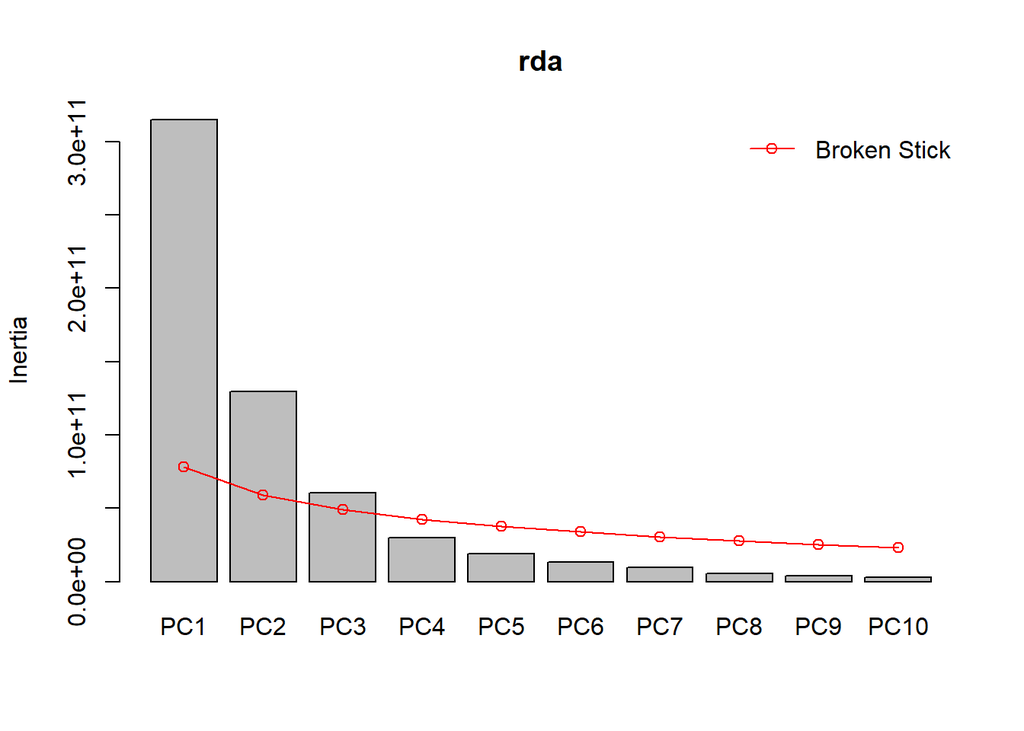

```r
# The 2 main axes: Relative_eig has to be > Broken_stick, i.e. more than just random interpretation OR at least cumul eig > cumul broken stick
otu_w_soil <- otu_table(phylo_for_UniFrac_soil)
rda <- rda(otu_w_soil) #raw data without the sample column which conflicts w/rda
screeplot(rda, bstick=TRUE)
```

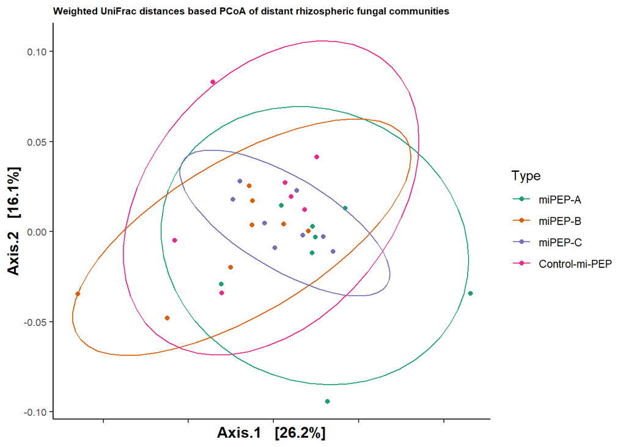

```r
#This graph shows that the 3 first axes are > random


WUF_soil <- plot_ordination(physeq = phylo_for_UniFrac_soil, ordination=PCOA_weighted_soil, color="Type")+ theme_classic()+ theme(axis.text.y = element_text (), axis.text.x = element_blank (), axis.text =element_text(size=8), axis.title=element_text(size=12,face="bold"))+scale_color_manual(values=c("#1B9E77", "#D95F02", "#7570B3", "#E7298A", "#66A61E", "#E6AB02", "#A6761D","#666666"))+stat_ellipse()
WUF_soil <- WUF_soil + ggtitle("Weighted UniFrac distances based PCoA of distant rhizospheric fungal communities") +theme(plot.title = element_text(size = 8, face = "bold"))
WUF_soil
```

```r
# en noir et blanc avec des formes
WUF_soil_nb <- plot_ordination(physeq = phylo_for_UniFrac_soil, ordination=PCOA_weighted_soil, shape="Type")+ theme_classic()+ theme(axis.text.y = element_text (), axis.text.x = element_blank (), axis.text =element_text(size=8), axis.title=element_text(size=12,face="bold"))+scale_shape_manual(values=c(0,1,2,3,19,15,8))+stat_ellipse()
WUF_soil_nb <- WUF_soil_nb  + ggtitle("Weighted UniFrac distances based PCoA of distant rhizospheric fungal communities") +theme(plot.title = element_text(size = 8, face = "bold"))

#Statistical analysis: permanova & beta-disper test

# Calculate distance matrix
WUF_soil <- phyloseq::distance(phylo_for_UniFrac_soil, method = "unifrac", weighted=TRUE)
sampledf_soil <- data.frame(sample_data(phylo_for_UniFrac_soil))
adonis(WUF_soil ~ Type, data = sampledf_soil)
```

```
## 'adonis' will be deprecated: use 'adonis2' instead
```

```
## $aov.tab
## Permutation: free
## Number of permutations: 999
##
## Terms added sequentially (first to last)
##
##           Df SumsOfSqs   MeanSqs F.Model      R2 Pr(>F)
## Type       3  0.019785 0.0065951  1.3348 0.12915    0.1
## Residuals 27  0.133410 0.0049411         0.87085
## Total     30  0.153196                   1.00000
##
## $call
## adonis(formula = WUF_soil ~ Type, data = sampledf_soil)
##
## $coefficients
```

[output cut: 1096 more lines]

```r
# If Type has a significant effect, check group dispersion
Disper_Type_soil = betadisper(WUF_soil, sampledf_soil$Type)
permutest(Disper_Type_soil, pairwise=TRUE, permutations=1000)
```

```
##
## Permutation test for homogeneity of multivariate dispersions
## Permutation: free
## Number of permutations: 1000
##
## Response: Distances
##           Df    Sum Sq    Mean Sq      F N.Perm Pr(>F)
## Groups     3 0.0035877 0.00119591 2.1563   1000 0.1169
## Residuals 27 0.0149745 0.00055461
##
## Pairwise comparisons:
## (Observed p-value below diagonal, permuted p-value above diagonal)
##                 miPEP-A  miPEP-B  miPEP-C Control-mi-PEP
## miPEP-A                 0.348651 0.024975         0.2068
## miPEP-B        0.344333          0.166833         0.6963
## miPEP-C        0.026311 0.149478                  0.1958
## Control-mi-PEP 0.199004 0.711952 0.208251
```

```r
#If the dispersion test is signif, it means that the Type effect is acutally only due to group dispersion, and not a real biological effect

pairwise.adonis(WUF_soil, sampledf_soil$Type)
```

```
## 'adonis' will be deprecated: use 'adonis2' instead
## 'adonis' will be deprecated: use 'adonis2' instead
## 'adonis' will be deprecated: use 'adonis2' instead
## 'adonis' will be deprecated: use 'adonis2' instead
## 'adonis' will be deprecated: use 'adonis2' instead
## 'adonis' will be deprecated: use 'adonis2' instead
```

```
##                       pairs Df   SumsOfSqs   F.Model         R2 p.value
## 1        miPEP-A vs miPEP-B  1 0.011198732 1.7631374 0.11185193   0.047
## 2        miPEP-A vs miPEP-C  1 0.004118328 0.7990507 0.05399338   0.733
## 3 miPEP-A vs Control-mi-PEP  1 0.009104569 1.4978427 0.10331486   0.109
## 4        miPEP-B vs miPEP-C  1 0.006187885 1.5927508 0.10214688   0.126
## 5 miPEP-B vs Control-mi-PEP  1 0.004812472 1.0213563 0.07284290   0.392
## 6 miPEP-C vs Control-mi-PEP  1 0.004034263 1.1788660 0.08314248   0.267
##   p.adjusted sig
## 1      0.282
## 2      1.000
## 3      0.654
## 4      0.756
## 5      1.000
## 6      1.000
```

Weighted UniFrac in unplanted samples…

```r
set.seed(711)
PCOA_weighted_unplanted <- ordinate(physeq = phylo_for_UniFrac_unplanted,  method = "PCoA", distance="unifrac", weighted=TRUE)
PCOA_weighted_unplanted
```

```
## $correction
## [1] "none" "1"
##
## $note
## [1] "No correction was applied to the negative eigenvalues"
##
## $values
##      Eigenvalues  Relative_eig Rel_corr_eig Broken_stick Cum_corr_eig
## 1   2.147736e-02  0.2332266825  0.168662169  0.133166238    0.1686622
## 2   1.703773e-02  0.1850158426  0.135939864  0.099832904    0.3046020
## 3   1.196775e-02  0.1299599931  0.098571622  0.083166238    0.4031737
## 4   1.017213e-02  0.1104610186  0.085337018  0.072055127    0.4885107
## 5   5.363548e-03  0.0582437735  0.049895432  0.063721793    0.5384061
## 6   5.162760e-03  0.0560633733  0.048415522  0.057055127    0.5868216
## 7   4.057621e-03  0.0440624614  0.040270102  0.051499571    0.6270917
## 8   3.484805e-03  0.0378421545  0.036048173  0.046737666    0.6631399
## 9   2.938500e-03  0.0319097259  0.032021635  0.042571000    0.6951615
## 10  2.089634e-03  0.0226917219  0.025765069  0.038867296    0.7209266
## 11  1.902969e-03  0.0206646933  0.024389257  0.035533963    0.7453159
## 12  1.644398e-03  0.0178568264  0.022483464  0.032503660    0.7677993
## 13  1.346062e-03  0.0146171431  0.020284583  0.029725882    0.7880839
## 14  1.209290e-03  0.0131319057  0.019276503  0.027161779    0.8073604
## 15  1.090187e-03  0.0118385452  0.018398656  0.024780827    0.8257591
## 16  1.042573e-03  0.0113214932  0.018047715  0.022558605    0.8438068
## 17  7.513187e-04  0.0081587104  0.015901029  0.020475271    0.8597078
## 18  6.260263e-04  0.0067981369  0.014977562  0.018514487    0.8746854
## 19  6.015896e-04  0.0065327737  0.014797452  0.016662635    0.8894828
## 20  4.973140e-04  0.0054004257  0.014028889  0.014908249    0.9035117
## 21  3.527431e-04  0.0038305029  0.012963330  0.013241582    0.9164750
## 22  2.745284e-04  0.0029811556  0.012386850  0.011654281    0.9288619
## 23  2.043858e-04  0.0022194636  0.011869864  0.010139129    0.9407318
## 24  1.122297e-04  0.0012187236  0.011190628  0.008689854    0.9519224
## 25  5.176320e-05  0.0005621063  0.010744960  0.007300965    0.9626673
## 26  0.000000e+00  0.0000000000  0.009862078  0.005967632    0.9725294
## 27 -6.802287e-05 -0.0007386731  0.008810747  0.004685580    0.9813402
## 28 -2.106635e-04 -0.0022876338  0.007680932  0.003451013    0.9890211
## 29 -3.639523e-04 -0.0039522261  0.006587957  0.002260536    0.9956091
## 30 -5.122430e-04 -0.0055625426  0.004390937  0.001111111    1.0000000
## 31 -8.103261e-04 -0.0087994830  0.000000000  0.000000000    1.0000000
## 32 -1.406072e-03 -0.0152687944  0.000000000  0.000000000    1.0000000
```

[output cut: 191 more lines]

```
## cSN8    -0.0024680037 -0.0059764810 -0.0007582019 -4.652783e-04  7.361551e-04
## ctrlSN1 -0.0013926105  0.0011128668  0.0009781474 -1.595940e-03 -2.803712e-04
## ctrlSN2  0.0023113876  0.0003045771 -0.0022392812  2.237645e-04  6.294263e-04
## ctrlSN3 -0.0021057205  0.0004423569 -0.0036405219 -4.661400e-04  6.418019e-04
## ctrlSN4 -0.0012194794 -0.0004530342  0.0040138612  2.710669e-04 -1.107267e-03
## ctrlSN5 -0.0053343770  0.0031719519 -0.0039929445  4.373707e-03 -2.467558e-03
## ctrlSN6  0.0029471360  0.0036802694 -0.0034515547 -3.571793e-03 -8.492473e-04
## ctrlSN7 -0.0032151876 -0.0084723525 -0.0024881961 -2.557445e-03 -1.714926e-03
## ctrlSN8  0.0007169282  0.0018190935  0.0017668381 -1.549147e-03  1.217353e-03
##
## $trace
## [1] 0.09208792
##
## attr(,"class")
## [1] "pcoa"
```

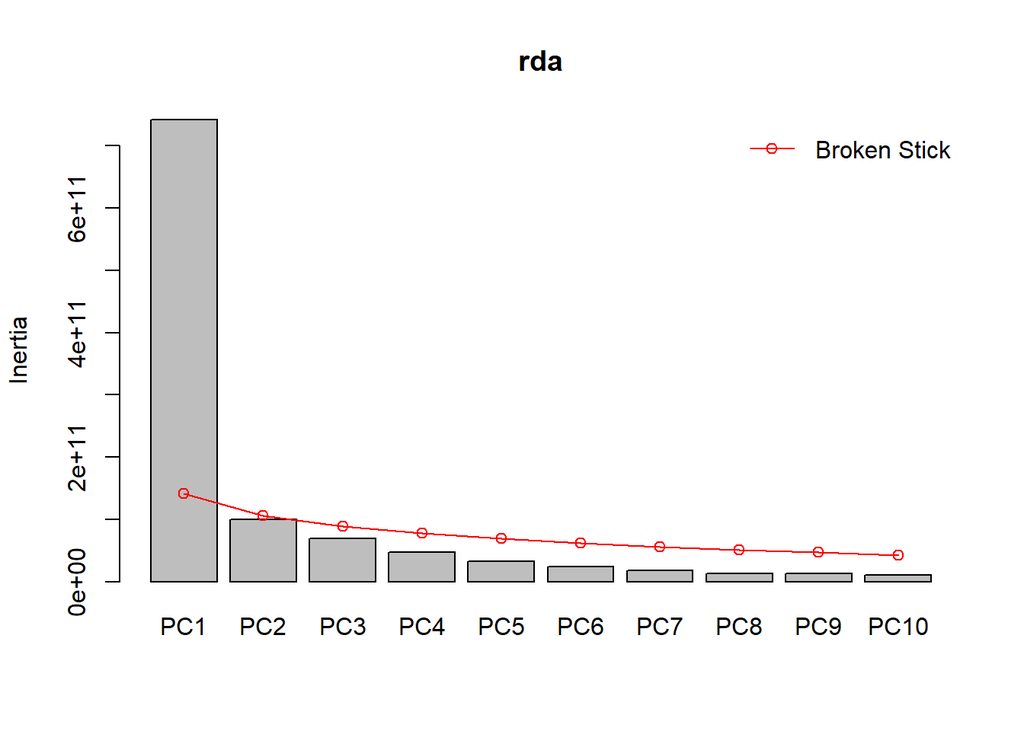

```r
# The 2 main axes: Relative_eig has to be > Broken_stick, i.e. more than just random interpretation OR at least cumul eig > cumul broken stick
otu_w_unplanted <- otu_table(phylo_for_UniFrac_unplanted)
rda <- rda(otu_w_unplanted) #raw data without the sample column which conflicts w/rda
screeplot(rda, bstick=TRUE)
```

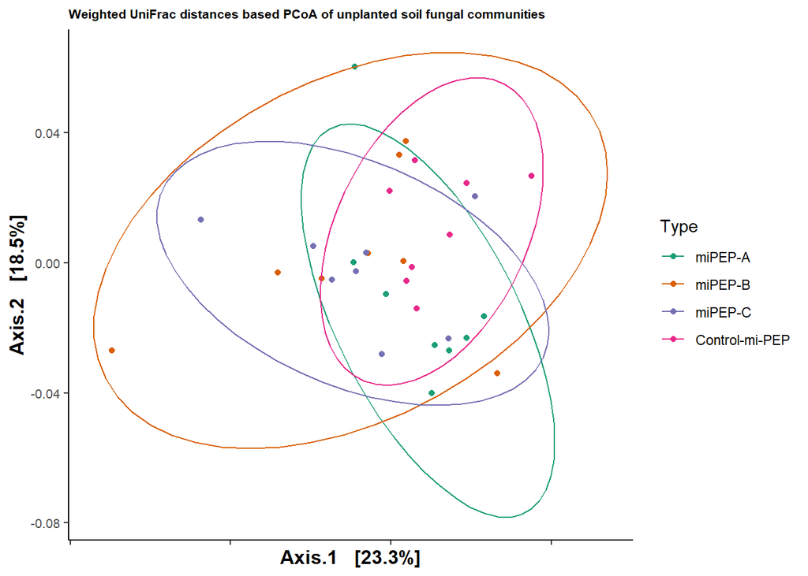

```r
#This graph shows that the 2nd axis is random

WUF_unplanted <- plot_ordination(physeq = phylo_for_UniFrac_unplanted, ordination=PCOA_weighted_unplanted, color="Type")+ theme_classic()+ theme(axis.text.y = element_text (), axis.text.x = element_blank (), axis.text =element_text(size=8), axis.title=element_text(size=12,face="bold"))+scale_color_manual(values=c("#1B9E77", "#D95F02", "#7570B3", "#E7298A", "#66A61E", "#E6AB02", "#A6761D","#666666"))+stat_ellipse()
WUF_unplanted <- WUF_unplanted + ggtitle("Weighted UniFrac distances based PCoA of unplanted soil fungal communities") +theme(plot.title = element_text(size = 8, face = "bold"))
WUF_unplanted
```

```r
# en noir et blanc avec des formes
WUF_unplanted_nb <- plot_ordination(physeq = phylo_for_UniFrac_unplanted, ordination=PCOA_weighted_unplanted, shape="Type")+ theme_classic()+ theme(axis.text.y = element_text (), axis.text.x = element_blank (), axis.text =element_text(size=8), axis.title=element_text(size=12,face="bold"))+scale_shape_manual(values=c(0,1,2,3,19,15,8))+stat_ellipse()
WUF_unplanted_nb <- WUF_unplanted_nb  + ggtitle("Weighted UniFrac distances based PCoA of unplanted soil fungal communities") +theme(plot.title = element_text(size = 8, face = "bold"))

#Statistical analysis: permanova & beta-disper test

# Calculate distance matrix
WUF_unplanted <- phyloseq::distance(phylo_for_UniFrac_unplanted, method = "unifrac", weighted=TRUE)
sampledf_unplanted <- data.frame(sample_data(phylo_for_UniFrac_unplanted))
adonis(WUF_unplanted ~ Type, data = sampledf_unplanted)
```

```
## 'adonis' will be deprecated: use 'adonis2' instead
```

```
## $aov.tab
## Permutation: free
## Number of permutations: 999
##
## Terms added sequentially (first to last)
##
##           Df SumsOfSqs   MeanSqs F.Model      R2 Pr(>F)
## Type       3  0.013166 0.0043888  1.5046 0.13883   0.04 *
## Residuals 28  0.081673 0.0029169         0.86117
## Total     31  0.094839                   1.00000
## ---
## Signif. codes:  0 '***' 0.001 '**' 0.01 '*' 0.05 '.' 0.1 ' ' 1
##
## $call
## adonis(formula = WUF_unplanted ~ Type, data = sampledf_unplanted)
```

[output cut: 1099 more lines]

```r
# If Type has a significant effect, check group dispersion
Disper_Type_unplanted = betadisper(WUF_unplanted, sampledf_unplanted$Type)
permutest(Disper_Type_unplanted, pairwise=TRUE, permutations=1000)
```

```
##
## Permutation test for homogeneity of multivariate dispersions
## Permutation: free
## Number of permutations: 1000
##
## Response: Distances
##           Df    Sum Sq    Mean Sq      F N.Perm Pr(>F)
## Groups     3 0.0004861 0.00016203 0.5346   1000 0.6723
## Residuals 28 0.0084863 0.00030308
##
## Pairwise comparisons:
## (Observed p-value below diagonal, permuted p-value above diagonal)
##                miPEP-A miPEP-B miPEP-C Control-mi-PEP
## miPEP-A                0.65934 0.61538         0.1958
## miPEP-B        0.64256         0.99600         0.5015
## miPEP-C        0.59345 0.99528                 0.3656
## Control-mi-PEP 0.18241 0.47568 0.38162
```

```r
#If the dispersion test is signif, it means that the Type effect is acutally only due to group dispersion, and not a real biological effect

pairwise.adonis(WUF_unplanted, sampledf_unplanted$Type)
```

```
## 'adonis' will be deprecated: use 'adonis2' instead
## 'adonis' will be deprecated: use 'adonis2' instead
## 'adonis' will be deprecated: use 'adonis2' instead
## 'adonis' will be deprecated: use 'adonis2' instead
## 'adonis' will be deprecated: use 'adonis2' instead
## 'adonis' will be deprecated: use 'adonis2' instead
```

```
##                       pairs Df   SumsOfSqs   F.Model         R2 p.value
## 1        miPEP-A vs miPEP-B  1 0.005020068 1.5064193 0.09714811   0.165
## 2        miPEP-A vs miPEP-C  1 0.004090820 1.2646656 0.08284921   0.220
## 3 miPEP-A vs Control-mi-PEP  1 0.004159844 1.4607116 0.09447894   0.152
## 4        miPEP-B vs miPEP-C  1 0.002279932 0.7635526 0.05171875   0.701
## 5 miPEP-B vs Control-mi-PEP  1 0.004461552 1.7165969 0.10922192   0.069
## 6 miPEP-C vs Control-mi-PEP  1 0.006320334 2.5267973 0.15289092   0.011
##   p.adjusted sig
## 1      0.990
## 2      1.000
## 3      0.912
## 4      1.000
## 5      0.414
## 6      0.066
```

Another type of analysis is to look at specific OTUs/ASVs that are specifically enriched or depleted in certain sample Types

1. Root samples

```r
library(DESeq2) # The DESeq2 package uses the raw OTU/ASV table (non rarefied phyloseq) and calculates a negative binomial GLM for each OTU/ASV , the Wald test for stats
#Convert phyloseq object into a DESeqDataSet object with dispersion estimates using "Type" as the main factor
ds2_roots <- phyloseq_to_deseq2(phylo_roots, ~ Type)
```

```
##   Note: levels of factors in the design contain characters other than
##   letters, numbers, '_' and '.'. It is recommended (but not required) to use
##   only letters, numbers, and delimiters '_' or '.', as these are safe characters
##   for column names in R. [This is a message, not a warning or an error]
```

```r
#Specify your reference group, or else it will use alphabetical order
ds2_roots$Type <- relevel(ds2_roots$Type, ref = "Control-mi-PEP")

#calculate geometric means prior to estimate size factors
gm_mean = function(x, na.rm=TRUE){exp(sum(log(x[x > 0]), na.rm=na.rm) / length(x))}
geoMeans = apply(counts(ds2_roots), 1, gm_mean)
ds2_roots= estimateSizeFactors(ds2_roots, geoMeans = geoMeans)
```

```
##   Note: levels of factors in the design contain characters other than
##   letters, numbers, '_' and '.'. It is recommended (but not required) to use
##   only letters, numbers, and delimiters '_' or '.', as these are safe characters
##   for column names in R. [This is a message, not a warning or an error]
```

```r
dds_roots <- DESeq(ds2_roots, test="Wald", fitType="parametric")
```

```
## -- note: fitType='parametric', but the dispersion trend was not well captured by the
##    function: y = a/x + b, and a local regression fit was automatically substituted.
##    specify fitType='local' or 'mean' to avoid this message next time.
```

```
##   Note: levels of factors in the design contain characters other than
##   letters, numbers, '_' and '.'. It is recommended (but not required) to use
##   only letters, numbers, and delimiters '_' or '.', as these are safe characters
##   for column names in R. [This is a message, not a warning or an error]
```

```
##   Note: levels of factors in the design contain characters other than
##   letters, numbers, '_' and '.'. It is recommended (but not required) to use
##   only letters, numbers, and delimiters '_' or '.', as these are safe characters
##   for column names in R. [This is a message, not a warning or an error]
```

```
##   Note: levels of factors in the design contain characters other than
##   letters, numbers, '_' and '.'. It is recommended (but not required) to use
##   only letters, numbers, and delimiters '_' or '.', as these are safe characters
##   for column names in R. [This is a message, not a warning or an error]
```

```
## -- replacing outliers and refitting for 175 genes
## -- DESeq argument 'minReplicatesForReplace' = 7
## -- original counts are preserved in counts(dds)
```

```
##   Note: levels of factors in the design contain characters other than
##   letters, numbers, '_' and '.'. It is recommended (but not required) to use
##   only letters, numbers, and delimiters '_' or '.', as these are safe characters
##   for column names in R. [This is a message, not a warning or an error]
```

```
##   Note: levels of factors in the design contain characters other than
##   letters, numbers, '_' and '.'. It is recommended (but not required) to use
##   only letters, numbers, and delimiters '_' or '.', as these are safe characters
##   for column names in R. [This is a message, not a warning or an error]
```

```r
##miPEP-A##

res_roots_miPEPa <- results(dds_roots, cooksCutoff = FALSE, contrast = c("Type","Control-mi-PEP","miPEP-A")) # gives the table showing the comparison of log2FoldChange between the "treated" and "untreated" group
res_roots_miPEPa_order = res_roots_miPEPa[order(res_roots_miPEPa$padj, na.last=NA), ] # order results by adjusted p-value (Benjamini-Hochberg correction)

alpha = 0.001
sigtab_roots_miPEPa = res_roots_miPEPa_order[which(res_roots_miPEPa_order$padj < alpha),]
sigtab_roots_miPEPa_top_47 <- sigtab_roots_miPEPa[c(1:47),] # select the 47 ASV with lowest p-adj
sigtab_roots_miPEPa_top_47 = cbind(as(sigtab_roots_miPEPa_top_47, "data.frame"), as(tax_table(phylo_roots)[rownames(sigtab_roots_miPEPa_top_47), ], "matrix"))
dim(sigtab_roots_miPEPa_top_47)
```

```
## [1] 47 18
```

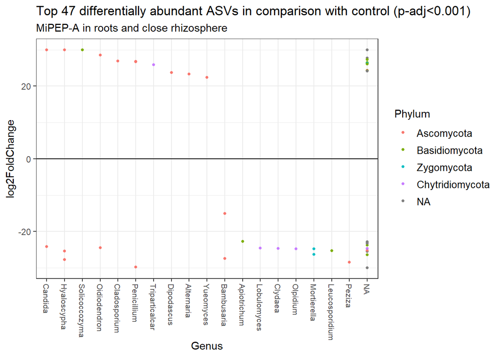

```r
########### Graphical representation #####
library("ggplot2")
theme_set(theme_bw())
scale_fill_discrete <- function(palname = "Set1", ...) {
    scale_fill_brewer(palette = palname, ...)
}
# Phylum order
x = tapply(sigtab_roots_miPEPa_top_47$log2FoldChange, sigtab_roots_miPEPa_top_47$Phylum, function(x) max(x))
x = sort(x, TRUE)
sigtab_roots_miPEPa_top_47$Phylum = factor(as.character(sigtab_roots_miPEPa_top_47$Phylum), levels=names(x))
# Genus order
x = tapply(sigtab_roots_miPEPa_top_47$log2FoldChange, sigtab_roots_miPEPa_top_47$Genus, function(x) max(x))
x = sort(x, TRUE)
sigtab_roots_miPEPa_top_47$Genus = factor(as.character(sigtab_roots_miPEPa_top_47$Genus), levels=names(x))
plot_miPEPa_roots <- ggplot(sigtab_roots_miPEPa_top_47, aes(x=Genus, y=log2FoldChange, color=Phylum)) + geom_point(size=1) +theme(axis.text.x = element_text(size=8, angle = -90, hjust = 0, vjust=0.5), legend.text = element_text(size = 10))+ geom_hline(yintercept=0, color="black") + labs(title = "Top 47 differentially abundant ASVs in comparison with control (p-adj<0.001)",subtitle = "MiPEP-A in roots and close rhizosphere")
plot_miPEPa_roots
```

```r
##miPEP-B##

res_roots_miPEPb <- results(dds_roots, cooksCutoff = FALSE, contrast = c("Type","Control-mi-PEP","miPEP-B")) # gives the table showing the comparison of log2FoldChange between the "treated" and "untreated" group
res_roots_miPEPb_order = res_roots_miPEPb[order(res_roots_miPEPb$padj, na.last=NA), ] # order results by adjusted p-value (Benjamini-Hochberg correction)

alpha = 0.001
sigtab_roots_miPEPb = res_roots_miPEPb_order[which(res_roots_miPEPb_order$padj < alpha),]
sigtab_roots_miPEPb_top_45 <- sigtab_roots_miPEPb[c(1:45),] # select the 45 ASV with lowest p-adj
sigtab_roots_miPEPb_top_45 = cbind(as(sigtab_roots_miPEPb_top_45, "data.frame"), as(tax_table(phylo_roots)[rownames(sigtab_roots_miPEPb_top_45), ], "matrix"))
dim(sigtab_roots_miPEPb_top_45)
```

```
## [1] 45 18
```

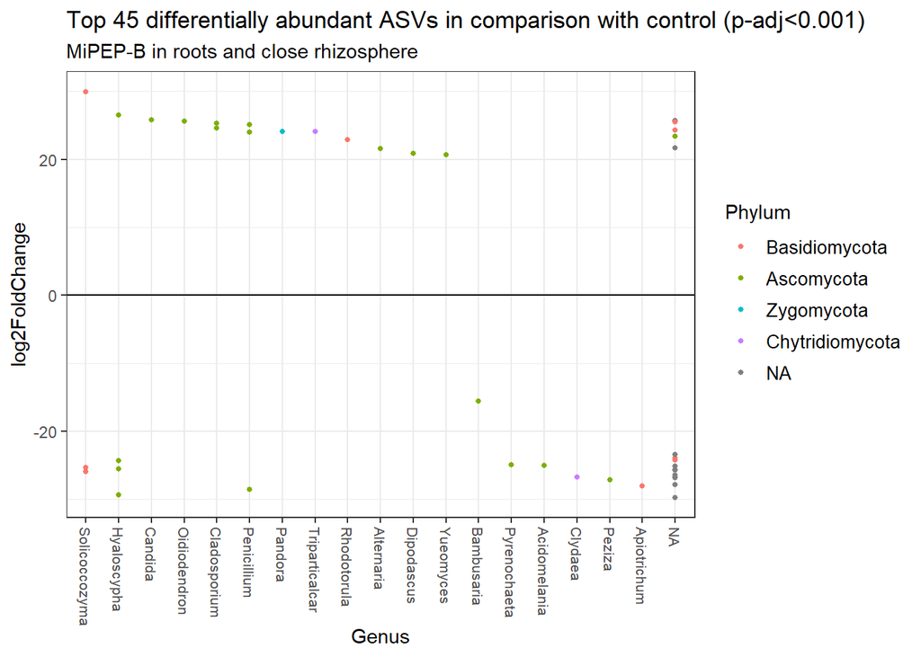

```r
########### Graphical representation #####
library("ggplot2")
theme_set(theme_bw())
scale_fill_discrete <- function(palname = "Set1", ...) {
    scale_fill_brewer(palette = palname, ...)
}
# Phylum order
x = tapply(sigtab_roots_miPEPb_top_45$log2FoldChange, sigtab_roots_miPEPb_top_45$Phylum, function(x) max(x))
x = sort(x, TRUE)
sigtab_roots_miPEPb_top_45$Phylum = factor(as.character(sigtab_roots_miPEPb_top_45$Phylum), levels=names(x))
# Genus order
x = tapply(sigtab_roots_miPEPb_top_45$log2FoldChange, sigtab_roots_miPEPb_top_45$Genus, function(x) max(x))
x = sort(x, TRUE)
sigtab_roots_miPEPb_top_45$Genus = factor(as.character(sigtab_roots_miPEPb_top_45$Genus), levels=names(x))
plot_miPEPb_roots <- ggplot(sigtab_roots_miPEPb_top_45, aes(x=Genus, y=log2FoldChange, color=Phylum)) + geom_point(size=1) +theme(axis.text.x = element_text(size=8, angle = -90, hjust = 0, vjust=0.5), legend.text = element_text(size = 10))+ geom_hline(yintercept=0, color="black") + labs(title = "Top 45 differentially abundant ASVs in comparison with control (p-adj<0.001)",subtitle = "MiPEP-B in roots and close rhizosphere")
plot_miPEPb_roots
```

```r
##miPEP-C##

res_roots_miPEPc <- results(dds_roots, cooksCutoff = FALSE, contrast = c("Type","Control-mi-PEP","miPEP-C")) # gives the table showing the comparison of log2FoldChange between the "treated" and "untreated" group
res_roots_miPEPc_order = res_roots_miPEPc[order(res_roots_miPEPc$padj, na.last=NA), ] # order results by adjusted p-value (Benjamini-Hochberg correction)

alpha = 0.001
sigtab_roots_miPEPc = res_roots_miPEPc_order[which(res_roots_miPEPc_order$padj < alpha),]
sigtab_roots_miPEPc_top_50 <- sigtab_roots_miPEPc[c(1:50),] # select the 50 ASV with lowest p-adj
sigtab_roots_miPEPc_top_50 = cbind(as(sigtab_roots_miPEPc_top_50, "data.frame"), as(tax_table(phylo_roots)[rownames(sigtab_roots_miPEPc_top_50), ], "matrix"))
dim(sigtab_roots_miPEPc_top_50)
```

```
## [1] 50 18
```

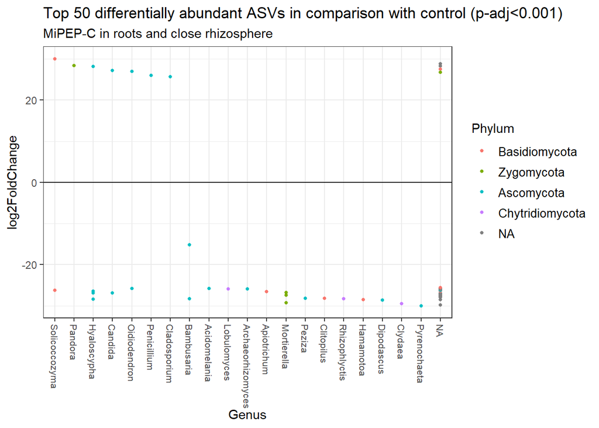

```r
#96 ASVs diff abundant

########### Graphical representation #####
library("ggplot2")
theme_set(theme_bw())
scale_fill_discrete <- function(palname = "Set1", ...) {
    scale_fill_brewer(palette = palname, ...)
}
# Phylum order
x = tapply(sigtab_roots_miPEPc_top_50$log2FoldChange, sigtab_roots_miPEPc_top_50$Phylum, function(x) max(x))
x = sort(x, TRUE)
sigtab_roots_miPEPc_top_50$Phylum = factor(as.character(sigtab_roots_miPEPc_top_50$Phylum), levels=names(x))
# Genus order
x = tapply(sigtab_roots_miPEPc_top_50$log2FoldChange, sigtab_roots_miPEPc_top_50$Genus, function(x) max(x))
x = sort(x, TRUE)
sigtab_roots_miPEPc_top_50$Genus = factor(as.character(sigtab_roots_miPEPc_top_50$Genus), levels=names(x))
plot_miPEPc_roots <- ggplot(sigtab_roots_miPEPc_top_50, aes(x=Genus, y=log2FoldChange, color=Phylum)) + geom_point(size=1) +theme(axis.text.x = element_text(size=8, angle = -90, hjust = 0, vjust=0.5), legend.text = element_text(size = 10))+ geom_hline(yintercept=0, color="black") + labs(title = "Top 50 differentially abundant ASVs in comparison with control (p-adj<0.001)",subtitle = "MiPEP-C in roots and close rhizosphere")
plot_miPEPc_roots
```

2. Soil samples

```r
library(DESeq2) # The DESeq2 package uses the raw OTU/ASV table (non rarefied phyloseq) and calculates a negative binomial GLM for each OTU/ASV , the Wald test for stats

#Convert phyloseq object into a DESeqDataSet object with dispersion estimates using "Type" as the main factor
ds2_soil <- phyloseq_to_deseq2(phylo_soil, ~ Type)
```

```
##   Note: levels of factors in the design contain characters other than
##   letters, numbers, '_' and '.'. It is recommended (but not required) to use
##   only letters, numbers, and delimiters '_' or '.', as these are safe characters
##   for column names in R. [This is a message, not a warning or an error]
```

```r
#Specify your reference group, or else it will use alphabetical order
ds2_soil$Type <- relevel(ds2_soil$Type, ref = "Control-mi-PEP")

#calculate geometric means prior to estimate size factors
gm_mean = function(x, na.rm=TRUE){exp(sum(log(x[x > 0]), na.rm=na.rm) / length(x))}
geoMeans = apply(counts(ds2_soil), 1, gm_mean)
ds2_soil= estimateSizeFactors(ds2_soil, geoMeans = geoMeans)
```

```
##   Note: levels of factors in the design contain characters other than
##   letters, numbers, '_' and '.'. It is recommended (but not required) to use
##   only letters, numbers, and delimiters '_' or '.', as these are safe characters
##   for column names in R. [This is a message, not a warning or an error]
```

```r
dds_soil <- DESeq(ds2_soil, test="Wald", fitType="parametric")
```

```
## -- note: fitType='parametric', but the dispersion trend was not well captured by the
##    function: y = a/x + b, and a local regression fit was automatically substituted.
##    specify fitType='local' or 'mean' to avoid this message next time.
```

```
##   Note: levels of factors in the design contain characters other than
##   letters, numbers, '_' and '.'. It is recommended (but not required) to use
##   only letters, numbers, and delimiters '_' or '.', as these are safe characters
##   for column names in R. [This is a message, not a warning or an error]
```

```
##   Note: levels of factors in the design contain characters other than
##   letters, numbers, '_' and '.'. It is recommended (but not required) to use
##   only letters, numbers, and delimiters '_' or '.', as these are safe characters
##   for column names in R. [This is a message, not a warning or an error]
```

```
##   Note: levels of factors in the design contain characters other than
##   letters, numbers, '_' and '.'. It is recommended (but not required) to use
##   only letters, numbers, and delimiters '_' or '.', as these are safe characters
##   for column names in R. [This is a message, not a warning or an error]
```

```
## -- replacing outliers and refitting for 181 genes
## -- DESeq argument 'minReplicatesForReplace' = 7
## -- original counts are preserved in counts(dds)
```

```
##   Note: levels of factors in the design contain characters other than
##   letters, numbers, '_' and '.'. It is recommended (but not required) to use
##   only letters, numbers, and delimiters '_' or '.', as these are safe characters
##   for column names in R. [This is a message, not a warning or an error]
```

```
##   Note: levels of factors in the design contain characters other than
##   letters, numbers, '_' and '.'. It is recommended (but not required) to use
##   only letters, numbers, and delimiters '_' or '.', as these are safe characters
##   for column names in R. [This is a message, not a warning or an error]
```

```r
##miPEP-A##

res_soil_miPEPa <- results(dds_soil, cooksCutoff = FALSE, contrast = c("Type","Control-mi-PEP","miPEP-A")) # gives the table showing the comparison of log2FoldChange between the "treated" and "untreated" group
res_soil_miPEPa_order = res_soil_miPEPa[order(res_soil_miPEPa$padj, na.last=NA), ] # order results by adjusted p-value (Benjamini-Hochberg correction)

alpha = 0.001
sigtab_soil_miPEPa = res_soil_miPEPa_order[which(res_soil_miPEPa_order$padj < alpha),]
sigtab_soil_miPEPa_top_50 <- sigtab_soil_miPEPa[c(1:50),] # select the 50 ASV with lowest p-adj
sigtab_soil_miPEPa_top_50 = cbind(as(sigtab_soil_miPEPa_top_50, "data.frame"), as(tax_table(phylo_soil)[rownames(sigtab_soil_miPEPa_top_50), ], "matrix"))
dim(sigtab_soil_miPEPa_top_50)
```

```
## [1] 50 18
```

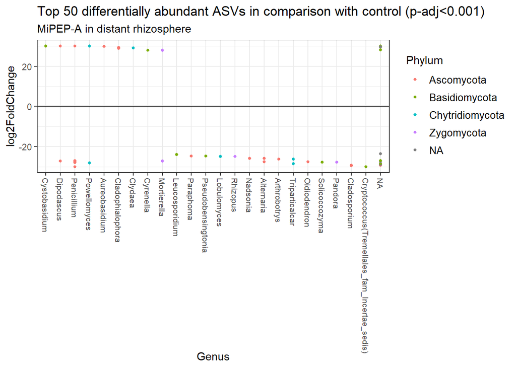

```r
########### Graphical representation #####
library("ggplot2")
theme_set(theme_bw())
scale_fill_discrete <- function(palname = "Set1", ...) {
    scale_fill_brewer(palette = palname, ...)
}
# Phylum order
x = tapply(sigtab_soil_miPEPa_top_50$log2FoldChange, sigtab_soil_miPEPa_top_50$Phylum, function(x) max(x))
x = sort(x, TRUE)
sigtab_soil_miPEPa_top_50$Phylum = factor(as.character(sigtab_soil_miPEPa_top_50$Phylum), levels=names(x))
# Genus order
x = tapply(sigtab_soil_miPEPa_top_50$log2FoldChange, sigtab_soil_miPEPa_top_50$Genus, function(x) max(x))
x = sort(x, TRUE)
sigtab_soil_miPEPa_top_50$Genus = factor(as.character(sigtab_soil_miPEPa_top_50$Genus), levels=names(x))
plot_miPEPa_soil <- ggplot(sigtab_soil_miPEPa_top_50, aes(x=Genus, y=log2FoldChange, color=Phylum)) + geom_point(size=1) +theme(axis.text.x = element_text(size=8, angle = -90, hjust = 0, vjust=0.5), legend.text = element_text(size = 10))+ geom_hline(yintercept=0, color="black") + labs(title = "Top 50 differentially abundant ASVs in comparison with control (p-adj<0.001)",subtitle = "MiPEP-A in distant rhizosphere")
plot_miPEPa_soil
```

```r
##miPEP-B##

res_soil_miPEPb <- results(dds_soil, cooksCutoff = FALSE, contrast = c("Type","Control-mi-PEP","miPEP-B")) # gives the table showing the comparison of log2FoldChange between the "treated" and "untreated" group
res_soil_miPEPb_order = res_soil_miPEPb[order(res_soil_miPEPb$padj, na.last=NA), ] # order results by adjusted p-value (Benjamini-Hochberg correction)

alpha = 0.001
sigtab_soil_miPEPb = res_soil_miPEPb_order[which(res_soil_miPEPb_order$padj < alpha),]
sigtab_soil_miPEPb_top_39 <- sigtab_soil_miPEPb[c(1:39),] # select the 39 ASV with lowest p-adj
sigtab_soil_miPEPb_top_39 = cbind(as(sigtab_soil_miPEPb_top_39, "data.frame"), as(tax_table(phylo_soil)[rownames(sigtab_soil_miPEPb_top_39), ], "matrix"))
dim(sigtab_soil_miPEPb_top_39)
```

```
## [1] 39 18
```

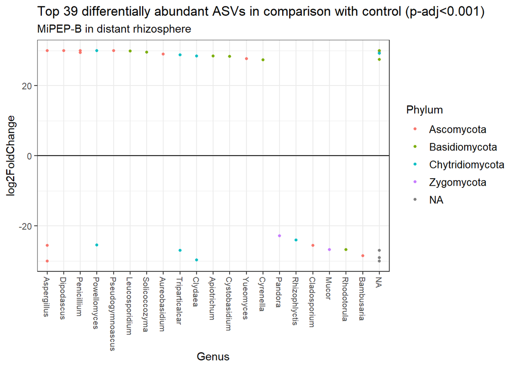

```r
########### Graphical representation #####
library("ggplot2")
theme_set(theme_bw())
scale_fill_discrete <- function(palname = "Set1", ...) {
    scale_fill_brewer(palette = palname, ...)
}
# Phylum order
x = tapply(sigtab_soil_miPEPb_top_39$log2FoldChange, sigtab_soil_miPEPb_top_39$Phylum, function(x) max(x))
x = sort(x, TRUE)
sigtab_soil_miPEPb_top_39$Phylum = factor(as.character(sigtab_soil_miPEPb_top_39$Phylum), levels=names(x))
# Genus order
x = tapply(sigtab_soil_miPEPb_top_39$log2FoldChange, sigtab_soil_miPEPb_top_39$Genus, function(x) max(x))
x = sort(x, TRUE)
sigtab_soil_miPEPb_top_39$Genus = factor(as.character(sigtab_soil_miPEPb_top_39$Genus), levels=names(x))
plot_miPEPb_soil <- ggplot(sigtab_soil_miPEPb_top_39, aes(x=Genus, y=log2FoldChange, color=Phylum)) + geom_point(size=1) +theme(axis.text.x = element_text(size=8, angle = -90, hjust = 0, vjust=0.5), legend.text = element_text(size = 10))+ geom_hline(yintercept=0, color="black") + labs(title = "Top 39 differentially abundant ASVs in comparison with control (p-adj<0.001)",subtitle = "MiPEP-B in distant rhizosphere")
plot_miPEPb_soil
```

```r
##miPEP-C##

res_soil_miPEPc <- results(dds_soil, cooksCutoff = FALSE, contrast = c("Type","Control-mi-PEP","miPEP-C")) # gives the table showing the comparison of log2FoldChange between the "treated" and "untreated" group
res_soil_miPEPc_order = res_soil_miPEPc[order(res_soil_miPEPc$padj, na.last=NA), ] # order results by adjusted p-value (Benjamini-Hochberg correction)

alpha = 0.001
sigtab_soil_miPEPc = res_soil_miPEPc_order[which(res_soil_miPEPc_order$padj < alpha),]
sigtab_soil_miPEPc_top_45 <- sigtab_soil_miPEPc[c(1:45),] # select the 45 ASV with lowest p-adj
sigtab_soil_miPEPc_top_45 = cbind(as(sigtab_soil_miPEPc_top_45, "data.frame"), as(tax_table(phylo_soil)[rownames(sigtab_soil_miPEPc_top_45), ], "matrix"))
dim(sigtab_soil_miPEPc_top_45)
```

```
## [1] 45 18
```

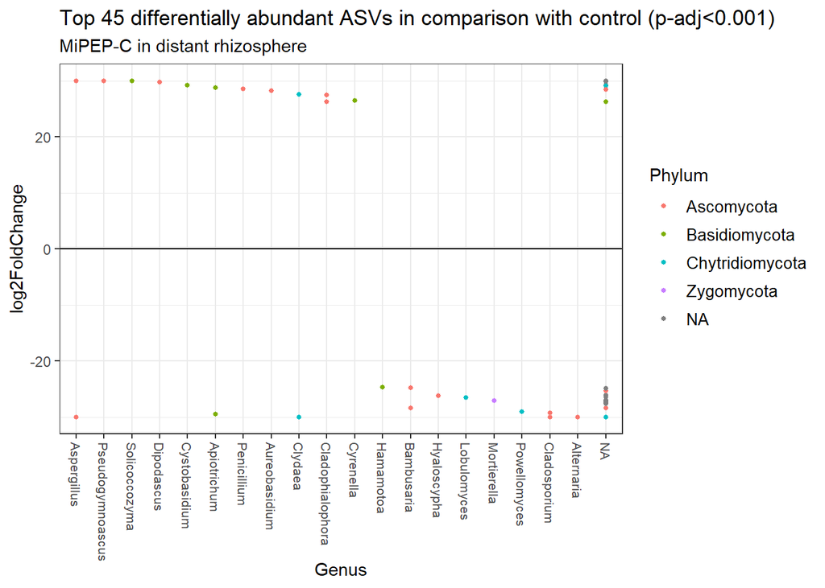

```r
########### Graphical representation #####
library("ggplot2")
theme_set(theme_bw())
scale_fill_discrete <- function(palname = "Set1", ...) {
    scale_fill_brewer(palette = palname, ...)
}
# Phylum order
x = tapply(sigtab_soil_miPEPc_top_45$log2FoldChange, sigtab_soil_miPEPc_top_45$Phylum, function(x) max(x))
x = sort(x, TRUE)
sigtab_soil_miPEPc_top_45$Phylum = factor(as.character(sigtab_soil_miPEPc_top_45$Phylum), levels=names(x))
# Genus order
x = tapply(sigtab_soil_miPEPc_top_45$log2FoldChange, sigtab_soil_miPEPc_top_45$Genus, function(x) max(x))
x = sort(x, TRUE)
sigtab_soil_miPEPc_top_45$Genus = factor(as.character(sigtab_soil_miPEPc_top_45$Genus), levels=names(x))
plot_miPEPc_soil <- ggplot(sigtab_soil_miPEPc_top_45, aes(x=Genus, y=log2FoldChange, color=Phylum)) + geom_point(size=1) +theme(axis.text.x = element_text(size=8, angle = -90, hjust = 0, vjust=0.5), legend.text = element_text(size = 10))+ geom_hline(yintercept=0, color="black") + labs(title = "Top 45 differentially abundant ASVs in comparison with control (p-adj<0.001)",subtitle = "MiPEP-C in distant rhizosphere")
plot_miPEPc_soil
```

3. Unplanted samples

```r
library(DESeq2) # The DESeq2 package uses the raw OTU/ASV table (non rarefied phyloseq) and calculates a negative binomial GLM for each OTU/ASV , the Wald test for stats

#Convert phyloseq object into a DESeqDataSet object with dispersion estimates using "Type" as the main factor
ds2_unplanted <- phyloseq_to_deseq2(phylo_unplanted, ~ Type)
```

```
##   Note: levels of factors in the design contain characters other than
##   letters, numbers, '_' and '.'. It is recommended (but not required) to use
##   only letters, numbers, and delimiters '_' or '.', as these are safe characters
##   for column names in R. [This is a message, not a warning or an error]
```

```r
#Specify your reference group, or else it will use alphabetical order
ds2_unplanted$Type <- relevel(ds2_unplanted$Type, ref = "Control-mi-PEP")

#calculate geometric means prior to estimate size factors
gm_mean = function(x, na.rm=TRUE){exp(sum(log(x[x > 0]), na.rm=na.rm) / length(x))}
geoMeans = apply(counts(ds2_unplanted), 1, gm_mean)
ds2_unplanted= estimateSizeFactors(ds2_unplanted, geoMeans = geoMeans)
```

```
##   Note: levels of factors in the design contain characters other than
##   letters, numbers, '_' and '.'. It is recommended (but not required) to use
##   only letters, numbers, and delimiters '_' or '.', as these are safe characters
##   for column names in R. [This is a message, not a warning or an error]
```

```r
dds_unplanted <- DESeq(ds2_unplanted, test="Wald", fitType="parametric")
```

```
## -- note: fitType='parametric', but the dispersion trend was not well captured by the
##    function: y = a/x + b, and a local regression fit was automatically substituted.
##    specify fitType='local' or 'mean' to avoid this message next time.
```

```
##   Note: levels of factors in the design contain characters other than
##   letters, numbers, '_' and '.'. It is recommended (but not required) to use
##   only letters, numbers, and delimiters '_' or '.', as these are safe characters
##   for column names in R. [This is a message, not a warning or an error]
```

```
##   Note: levels of factors in the design contain characters other than
##   letters, numbers, '_' and '.'. It is recommended (but not required) to use
##   only letters, numbers, and delimiters '_' or '.', as these are safe characters
##   for column names in R. [This is a message, not a warning or an error]
```

```
##   Note: levels of factors in the design contain characters other than
##   letters, numbers, '_' and '.'. It is recommended (but not required) to use
##   only letters, numbers, and delimiters '_' or '.', as these are safe characters
##   for column names in R. [This is a message, not a warning or an error]
```

```
## -- replacing outliers and refitting for 205 genes
## -- DESeq argument 'minReplicatesForReplace' = 7
## -- original counts are preserved in counts(dds)
```

```
##   Note: levels of factors in the design contain characters other than
##   letters, numbers, '_' and '.'. It is recommended (but not required) to use
##   only letters, numbers, and delimiters '_' or '.', as these are safe characters
##   for column names in R. [This is a message, not a warning or an error]
```

```
##   Note: levels of factors in the design contain characters other than
##   letters, numbers, '_' and '.'. It is recommended (but not required) to use
##   only letters, numbers, and delimiters '_' or '.', as these are safe characters
##   for column names in R. [This is a message, not a warning or an error]
```

```r
##miPEP-A##

res_unplanted_miPEPa <- results(dds_unplanted, cooksCutoff = FALSE, contrast = c("Type","Control-mi-PEP","miPEP-A")) # gives the table showing the comparison of log2FoldChange between the "treated" and "untreated" group
res_unplanted_miPEPa_order = res_unplanted_miPEPa[order(res_unplanted_miPEPa$padj, na.last=NA), ] # order results by adjusted p-value (Benjamini-Hochberg correction)

alpha = 0.001
sigtab_unplanted_miPEPa = res_unplanted_miPEPa_order[which(res_unplanted_miPEPa_order$padj < alpha),]
sigtab_unplanted_miPEPa_top_43 <- sigtab_unplanted_miPEPa[c(1:43),] # select the 43 ASV with lowest p-adj
sigtab_unplanted_miPEPa_top_43 = cbind(as(sigtab_unplanted_miPEPa_top_43, "data.frame"), as(tax_table(phylo_unplanted)[rownames(sigtab_unplanted_miPEPa_top_43), ], "matrix"))
dim(sigtab_unplanted_miPEPa_top_43)
```

```
## [1] 43 18
```

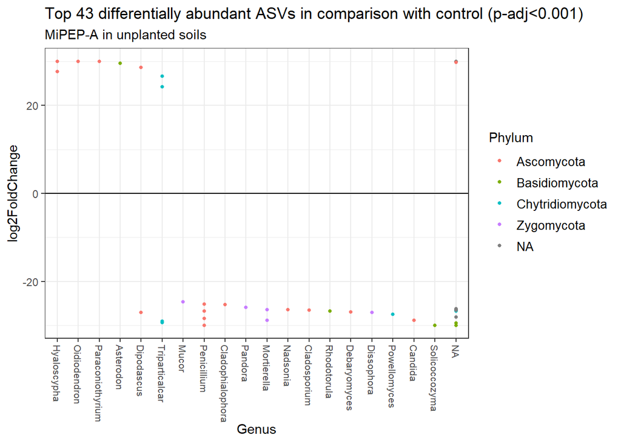

```r
########### Graphical representation #####
library("ggplot2")
theme_set(theme_bw())
scale_fill_discrete <- function(palname = "Set1", ...) {
    scale_fill_brewer(palette = palname, ...)
}
# Phylum order
x = tapply(sigtab_unplanted_miPEPa_top_43$log2FoldChange, sigtab_unplanted_miPEPa_top_43$Phylum, function(x) max(x))
x = sort(x, TRUE)
sigtab_unplanted_miPEPa_top_43$Phylum = factor(as.character(sigtab_unplanted_miPEPa_top_43$Phylum), levels=names(x))
# Genus order
x = tapply(sigtab_unplanted_miPEPa_top_43$log2FoldChange, sigtab_unplanted_miPEPa_top_43$Genus, function(x) max(x))
x = sort(x, TRUE)
sigtab_unplanted_miPEPa_top_43$Genus = factor(as.character(sigtab_unplanted_miPEPa_top_43$Genus), levels=names(x))
plot_miPEPa_unplanted <- ggplot(sigtab_unplanted_miPEPa_top_43, aes(x=Genus, y=log2FoldChange, color=Phylum)) + geom_point(size=1) +theme(axis.text.x = element_text(size=8, angle = -90, hjust = 0, vjust=0.5), legend.text = element_text(size = 10))+ geom_hline(yintercept=0, color="black") + labs(title = "Top 43 differentially abundant ASVs in comparison with control (p-adj<0.001)",subtitle = "MiPEP-A in unplanted soils")
plot_miPEPa_unplanted
```

```r
##miPEP-B##

res_unplanted_miPEPb <- results(dds_unplanted, cooksCutoff = FALSE, contrast = c("Type","Control-mi-PEP","miPEP-B")) # gives the table showing the comparison of log2FoldChange between the "treated" and "untreated" group
res_unplanted_miPEPb_order = res_unplanted_miPEPb[order(res_unplanted_miPEPb$padj, na.last=NA), ] # order results by adjusted p-value (Benjamini-Hochberg correction)

alpha = 0.001
sigtab_unplanted_miPEPb = res_unplanted_miPEPb_order[which(res_unplanted_miPEPb_order$padj < alpha),]
sigtab_unplanted_miPEPb_top_48 <- sigtab_unplanted_miPEPb[c(1:48),] # select the 48 ASV with lowest p-adj
sigtab_unplanted_miPEPb_top_48 = cbind(as(sigtab_unplanted_miPEPb_top_48, "data.frame"), as(tax_table(phylo_unplanted)[rownames(sigtab_unplanted_miPEPb_top_48), ], "matrix"))
dim(sigtab_unplanted_miPEPb_top_48)
```

```
## [1] 48 18
```

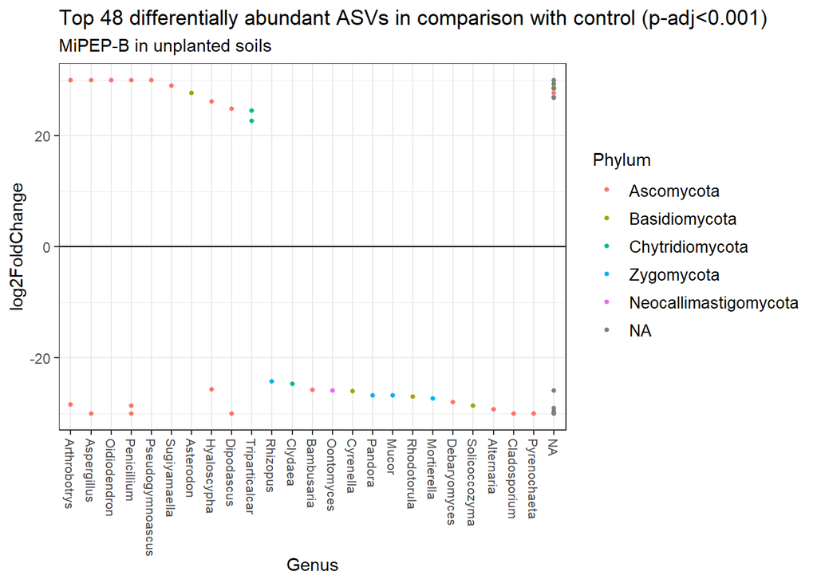

```r
########### Graphical representation #####
library("ggplot2")
theme_set(theme_bw())
scale_fill_discrete <- function(palname = "Set1", ...) {
    scale_fill_brewer(palette = palname, ...)
}
# Phylum order
x = tapply(sigtab_unplanted_miPEPb_top_48$log2FoldChange, sigtab_unplanted_miPEPb_top_48$Phylum, function(x) max(x))
x = sort(x, TRUE)
sigtab_unplanted_miPEPb_top_48$Phylum = factor(as.character(sigtab_unplanted_miPEPb_top_48$Phylum), levels=names(x))
# Genus order
x = tapply(sigtab_unplanted_miPEPb_top_48$log2FoldChange, sigtab_unplanted_miPEPb_top_48$Genus, function(x) max(x))
x = sort(x, TRUE)
sigtab_unplanted_miPEPb_top_48$Genus = factor(as.character(sigtab_unplanted_miPEPb_top_48$Genus), levels=names(x))
plot_miPEPb_unplanted <- ggplot(sigtab_unplanted_miPEPb_top_48, aes(x=Genus, y=log2FoldChange, color=Phylum)) + geom_point(size=1) +theme(axis.text.x = element_text(size=8, angle = -90, hjust = 0, vjust=0.5), legend.text = element_text(size = 10))+ geom_hline(yintercept=0, color="black") + labs(title = "Top 48 differentially abundant ASVs in comparison with control (p-adj<0.001)",subtitle = "MiPEP-B in unplanted soils")
plot_miPEPb_unplanted
```

```r
##miPEP-C##

res_unplanted_miPEPc <- results(dds_unplanted, cooksCutoff = FALSE, contrast = c("Type","Control-mi-PEP","miPEP-C")) # gives the table showing the comparison of log2FoldChange between the "treated" and "untreated" group
res_unplanted_miPEPc_order = res_unplanted_miPEPc[order(res_unplanted_miPEPc$padj, na.last=NA), ] # order results by adjusted p-value (Benjamini-Hochberg correction)

alpha = 0.001
sigtab_unplanted_miPEPc = res_unplanted_miPEPc_order[which(res_unplanted_miPEPc_order$padj < alpha),]
sigtab_unplanted_miPEPc_top_39 <- sigtab_unplanted_miPEPc[c(1:39),] # select the 39 ASV with lowest p-adj
sigtab_unplanted_miPEPc_top_39 = cbind(as(sigtab_unplanted_miPEPc_top_39, "data.frame"), as(tax_table(phylo_unplanted)[rownames(sigtab_unplanted_miPEPc_top_39), ], "matrix"))
dim(sigtab_unplanted_miPEPc_top_39)
```

```
## [1] 39 18
```

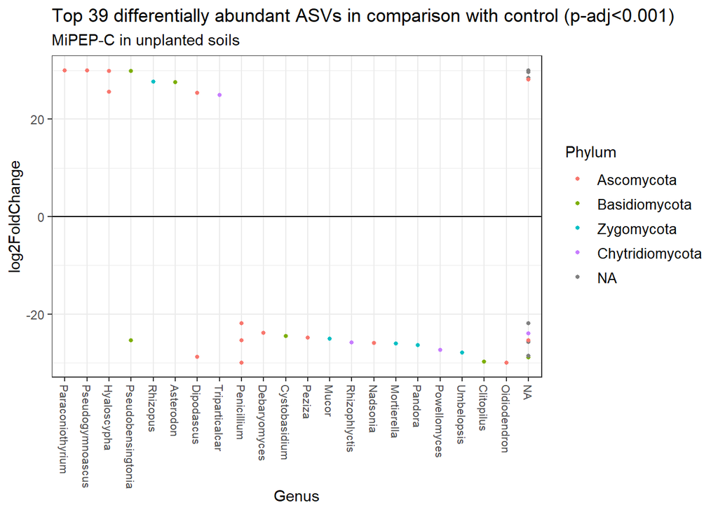

```r
########### Graphical representation #####
library("ggplot2")
theme_set(theme_bw())
scale_fill_discrete <- function(palname = "Set1", ...) {
    scale_fill_brewer(palette = palname, ...)
}
# Phylum order
x = tapply(sigtab_unplanted_miPEPc_top_39$log2FoldChange, sigtab_unplanted_miPEPc_top_39$Phylum, function(x) max(x))
x = sort(x, TRUE)
sigtab_unplanted_miPEPc_top_39$Phylum = factor(as.character(sigtab_unplanted_miPEPc_top_39$Phylum), levels=names(x))
# Genus order
x = tapply(sigtab_unplanted_miPEPc_top_39$log2FoldChange, sigtab_unplanted_miPEPc_top_39$Genus, function(x) max(x))
x = sort(x, TRUE)
sigtab_unplanted_miPEPc_top_39$Genus = factor(as.character(sigtab_unplanted_miPEPc_top_39$Genus), levels=names(x))
plot_miPEPc_unplanted <- ggplot(sigtab_unplanted_miPEPc_top_39, aes(x=Genus, y=log2FoldChange, color=Phylum)) + geom_point(size=1) +theme(axis.text.x = element_text(size=8, angle = -90, hjust = 0, vjust=0.5), legend.text = element_text(size = 10))+ geom_hline(yintercept=0, color="black") + labs(title = "Top 39 differentially abundant ASVs in comparison with control (p-adj<0.001)",subtitle = "MiPEP-C in unplanted soils")
plot_miPEPc_unplanted
```

Indicator Species

1. Roots samples

```r
#library(indicspecies)

# Export the OTU table, with a Sample column, Type column and then ASV & abundances per column
#OTU_table_phylo_roots <- otu_table(phylo_roots)
#head(OTU_table_phylo_roots)
#write.table(OTU_table_phylo_roots, "OTU_table_phylo_roots.txt")

#Re-import the table OTU_table_phylo_roots_1.xlsx
#OTU_table_phylo_roots_1<-read_excel("C:/Users/hmiddleton/Dropbox/Projet_Mutants_miPEPs_miRNA/Harriet/Metabarcoding_mutants_and_miPEP/Analyses_métabarcoding/miPEP_H/ITS/OTU_table_phylo_roots_1.xlsx")

#abund_roots = OTU_table_phylo_roots_1[,3:ncol(OTU_table_phylo_roots_1)] #ASV abundance starts at column 3
#Type = OTU_table_phylo_roots_1$Type # create a vector that contains the information from the "Type" column
#set.seed(771)
#inv_roots = multipatt(abund_roots, Type, func = "r.g", control = how(nperm=9999))
#summary(inv_roots)
```

2. Soil samples

```r
#https://jkzorz.github.io/2019/07/02/Indicator-species-analysis.html
#library(indicspecies)

# Export the OTU table, with a Sample column, Type column and then ASV & abundances per column
#OTU_table_phylo_soil <- otu_table(phylo_soil)
#head(OTU_table_phylo_soil)
#write.table(OTU_table_phylo_soil, "OTU_table_phylo_soil.txt")

#Re-import the table OTU_table_phylo_soil_1.xlsx
#OTU_table_phylo_soil_1<-read_excel("C:/Users/hmiddleton/Dropbox/Projet_Mutants_miPEPs_miRNA/Harriet/Metabarcoding_mutants_and_miPEP/Analyses_métabarcoding/miPEP_H/ITS/OTU_table_phylo_soil_1.xlsx")

#abund_soil = OTU_table_phylo_soil_1[,3:ncol(OTU_table_phylo_soil_1)] #ASV abundance starts at column 3
#Type = OTU_table_phylo_soil_1$Type # create a vector that contains the information from the "Type" column
#set.seed(771)
#inv_soil = multipatt(abund_soil, Type, func = "r.g", control = how(nperm=9999))
#summary(inv_soil)

#IndVal.g is the corrected version of IndVal for unequal group sizes. "r." measures correlation between two binary vectors: r.g. is a correction of this measurement which uses abundance and not just presence/absence
#A = specificity or positive predictive value
#(proba que le groupe investigué appartienne bien au groupe target, du fait que cette espèce indic soit dedans),
# B= fidelity or sensitivity: (proba qu'une espèce indic appartienne bien au groupe target)
```

3. Unplanted samples

```r
#library(indicspecies)

# Export the OTU table, with a Sample column, Type column and then ASV & abundances per column
#OTU_table_phylo_unplanted <- otu_table(phylo_unplanted)
#head(OTU_table_phylo_unplanted)
#write.table(OTU_table_phylo_unplanted, "OTU_table_phylo_unplanted.txt")

#Re-import the table OTU_table_phylo_unplanted_1.xlsx
#OTU_table_phylo_unplanted_1<-read_excel("C:/Users/hmiddleton/Dropbox/Projet_Mutants_miPEPs_miRNA/Harriet/Metabarcoding_mutants_and_miPEP/Analyses_métabarcoding/miPEP_H/ITS/OTU_table_phylo_unplanted_1.xlsx")

#abund_unplanted = OTU_table_phylo_unplanted_1[,3:ncol(OTU_table_phylo_unplanted_1)] #ASV abundance starts at column 3
#Type = OTU_table_phylo_unplanted_1$Type # create a vector that contains the information from the "Type" column
#set.seed(771)
#inv_unplanted = multipatt(abund_unplanted, Type, func = "r.g", control = how(nperm=9999))
#summary(inv_unplanted)
```